# 장애인 전용 저상 버스 정류장 입지 선정

> 1. 데이터 수집
> 2. 데이터 탐색(EDA) & 전처리
> 3. 데이터 시각화
> 4. 데이터 분석  
>    4-1) 상관관계 분석  
>    4-2) k-means 클러스터링  
>    4-3) 회귀분석
> 5. 결과

## 1. 데이터 수집

서울시 장애인 콜택시 일별 현황 open api를 통해 데이터 가져오기(https://data.seoul.go.kr/dataList/OA-15558/A/1/datasetView.do) 해당 API는 json은 제공이 안되고 xml만 서비스만 가능해서 xml을 json으로 변경해서 데이터 프레임으로 저장하는 과정을 거침

```python
pip install xmltodict
```

```python
import pandas as pd
import urllib.request as ul
import xmltodict
import datetime
from datetime import datetime, timedelta
import json
import seaborn as sns
import matplotlib.pyplot as plt
```

```python
#--!! 이부분은 미리 돌려서 엑셀로 뽑았습니다!! --#


## for 문을 날짜 리스트에 따라 돌려가며 부르기
dt_index = pd.date_range(start='20210701', end='20210702') #기간 설정하기
# pandas.date_range(start='20160901', end='20161031',freq='W-MON')
# 을 하면 해당 기간 매주 월요일들만 추출합니다.
dt_list = dt_index.strftime("%Y%m%d").tolist() # 리스트로 변환
df = pd.DataFrame()

# for 문으로 하루치 데이터 부르는 작업을 리스트에 저장된 기간에 반복한다.
# url을 바꿔가면서 데이터를 부르기 위해서 url의 끝부문 날짜에 변수 i를 넣어준다.
# 불러온 데이터를 append 메소드를 이용하여 데이터프레임 하단에 붙인다.
for i in dt_list:
    url="http://openapi.seoul.go.kr:8088/6b7141736268733239335174536676/xml/disabledCalltaxi/1/100/" + i
    request = ul.Request(url)
    #url의 데이터를 요청함

    response = ul.urlopen(request)
    #요청받은 데이터를 열어줌

    rescode = response.getcode()
    #제대로 데이터가 수신됐는지 확인하는 코드 성공시 200

    if(rescode == 200):
        responseData = response.read()
        #요청받은 데이터를 읽음
        rD = xmltodict.parse(responseData)
        #XML형식의 데이터를 dict형식으로 변환시켜줌

        rDJ = json.dumps(rD)
        #dict 형식의 데이터를 json형식으로 변환

        rDD = json.loads(rDJ)
        #json형식의 데이터를 dict 형식으로 변환

        taxi_data = rDD["openXMLSEOUL"]["ROW"]["list"]["item"]
        #해당 dict형식의 파일의 item을 사용하기 편하도록 taxi_data에 저장

        # df0=pd.DataFrame(taxi_data, columns=['no','cartype','receipttime','settime','ridetime','startpos1','startpos2','endpos1','endpos2']) # 데이터 프레임으로 변환

        df=df.append(taxi_data) # for 로 돌린 다른 데이터 프레임과 연결(병햡)
```

```python
# 엑셀로 저장
df.to_excel('서울열린데이터광장20210701-20210930(3분기).xlsx') ## 날짜 신경 쓰기
```

## 2. 데이터 탐색(EDA) & 전처리

```python
# 데이터 불러오기
# 두개다 열이 10만개 정도되는 굉장히 큰 파일입니다. 데이터를 불러올때까지 시간이 상당히 걸립니다.
df20 = pd.read_excel('./data/raw데이터/서울열린데이터광장2020년1년.xlsx')
df20
```

|  | Unnamed: 0 | no | cartype | receipttime | settime | ridetime | startpos1 | startpos2 | endpos1 | endpos2 |
| --- | --- | --- | --- | --- | --- | --- | --- | --- | --- | --- |
| 0 | 0.0 | 5761.0 | 중형승합 | 2020-01-01 오전 12:01:00 | 2020-01-01 오전 3:01:40 | 2020-01-01 오전 3:19:01 | 중구 | 명동 | 강남구 | 일원본동 |
| 1 | 1.0 | 9567.0 | 중형승합 | 2020-01-01 오전 12:26:00 | 2020-01-01 오전 3:07:51 | 2020-01-01 오전 3:35:13 | 중구 | 신당제5동 | 중랑구 | 중화제2동 |
| 2 | 2.0 | 1563.0 | 중형 승합 | 2020-01-01 오전 12:37:00 | 2020-01-01 오전 3:01:24 | 2020-01-01 오전 3:24:33 | 강북구 | 번제3동 | 의정부시 | 자금동 |
| 3 | 3.0 | 5761.0 | 중형승합 | 2020-01-01 오전 12:39:00 | 2020-01-01 오전 4:15:07 | 2020-01-01 오전 4:28:58 | 영등포구 | 여의동 | 관악구 | 난곡동 |
| 4 | 4.0 | 9567.0 | 중형승합 | 2020-01-01 오전 12:52:00 | 2020-01-01 오전 4:13:50 | 2020-01-01 오전 4:35:41 | 금천구 | 독산제1동 | 서초구 | 반포4동 |
| ... | ... | ... | ... | ... | ... | ... | ... | ... | ... | ... |
| 975386 | 2628.0 | 804.0 | 중형승합 | 2020-12-31 오후 11:21:00 | 2020-12-31 오후 11:23:40 | 2020-12-31 오후 11:39:34 | 강북구 | 수유제2동 | 강북구 | 삼양동 |
| 975387 | 2629.0 | 826.0 | 중형승합 | 2020-12-31 오후 11:23:00 | 2020-12-31 오후 11:30:47 | 2020-12-31 오후 11:45:47 | 관악구 | 은천동 | 관악구 | 은천동 |
| 975388 | 2630.0 | 5787.0 | 중형승합 | 2020-12-31 오후 11:30:00 | 2020-12-31 오후 11:32:48 | 2020-12-31 오후 11:57:21 | 은평구 | 신사제1동 | 강서구 | 가양제2동 |
| 975389 | 2631.0 | 8220.0 | 중형승합 | 2020-12-31 오후 11:42:00 | 2020-12-31 오후 11:48:58 | 2021-01-01 오전 12:21:46 | 강북구 | 수유제2동 | 강서구 | 등촌제3동 |
| 975390 | 2632.0 | 7815.0 | 중형승합 | 2020-12-31 오후 11:59:00 | 2021-01-01 오전 12:07:37 | 2021-01-01 오전 12:51:16 | 성동구 | 왕십리제2동 | 부천시원미구 | 상3동 |

975391 rows × 10 columns

```python
df21 = pd.read_excel('./data/raw데이터/서울열린데이터광장2021년1년.xlsx')
df21
```

|  | Unnamed: 0 | no | cartype | receipttime | settime | ridetime | startpos1 | startpos2 | endpos1 | endpos2 |
| --- | --- | --- | --- | --- | --- | --- | --- | --- | --- | --- |
| 0 | 0 | 5725 | 중형승합 | 2021-01-01 오전 12:04:45 | 2021-01-01 오전 12:05:54 | 2021-01-01 오전 12:28:00 | 강남구 | 수서동 | 강남구 | 개포4동 |
| 1 | 1 | 7846 | 중형 승합 | 2021-01-01 오전 12:06:54 | 2021-01-01 오전 12:18:20 | 2021-01-01 오전 12:38:11 | 관악구 | 대학동 | 광진구 | 구의제3동 |
| 2 | 2 | 5643 | 중형승합 | 2021-01-01 오전 12:21:06 | 2021-01-01 오전 12:30:51 | 2021-01-01 오전 1:11:28 | 서초구 | 서초1동 | 구로구 | 가리봉동 |
| 3 | 3 | 8239 | 중형승합 | 2021-01-01 오전 12:26:00 | 2021-01-01 오전 12:34:10 | 2021-01-01 오전 12:57:07 | 성동구 | 왕십리도선동 | 강남구 | 수서동 |
| 4 | 4 | 1303 | 중형승합 | 2021-01-01 오전 12:45:00 | 2021-01-01 오전 12:50:25 | 2021-01-01 오전 1:12:04 | 도봉구 | 쌍문제2동 | 노원구 | 상계1동 |
| ... | ... | ... | ... | ... | ... | ... | ... | ... | ... | ... |
| 1009574 | 1420 | 7907 | 중형승합 | 2021-10-31 오후 11:25:00 | 2021-10-31 오후 11:28:43 | 2021-10-31 오후 11:37:07 | 강남구 | 청담동 | 강서구 | 등촌제3동 |
| 1009575 | 1421 | 5798 | 중형승합 | 2021-10-31 오후 11:26:00 | 2021-10-31 오후 11:27:53 | 2021-10-31 오후 11:39:47 | 마포구 | 신수동 | 송파구 | 잠실2동 |
| 1009576 | 1422 | 1553 | 중형 승합 | 2021-10-31 오후 11:29:30 | 2021-10-31 오후 11:32:58 | 2021-10-31 오후 11:47:49 | 송파구 | 방이2동 | 남양주시 | 호평동 |
| 1009577 | 1423 | 7654 | 중형승합 | 2021-10-31 오후 11:47:08 | 2021-10-31 오후 11:57:07 | 2021-11-01 오전 12:21:47 | 용산구 | 남영동 | 서대문구 | 북가좌제2동 |
| 1009578 | 1424 | 7641 | 중형승합 | 2021-10-31 오후 11:53:17 | 2021-11-01 오전 12:03:42 | 2021-11-01 오전 12:26:02 | 중구 | 회현동 | 도봉구 | 도봉제2동 |

1009579 rows × 10 columns

```python
# 컬럼 삭제
del df20['Unnamed: 0']
del df21['Unnamed: 0']
```

컬럼 설명

```
1. NO   차량고유번호
2. CARTYPE  차량타입
3. RECEIPTIME   예정일시 : 고객이 콜택시 접수 신청한 시각
4. SETTIME  배차일시 : 고객 접수후 그 고객한테 택시가 배차된 시각
5. RIDETIME 승차일시 : 고객 해당 차량에 승차한 시각
6. STARTPOS1    출발지구군
7. STARTPOS2    출발지상세
8. ENDPOS1  목적지구군
9. ENDPOS2  목적지상세
```

### 데이터 탐색(EDA)

```python
df20.shape, df21.shape
```

```
((975391, 9), (1009579, 9))
```

```python
df20.info(), df21.info()
```

```
<class 'pandas.core.frame.DataFrame'>
RangeIndex: 975391 entries, 0 to 975390
Data columns (total 9 columns):
 #   Column       Non-Null Count   Dtype
---  ------       --------------   -----
 0   no           975367 non-null  float64
 1   cartype      975366 non-null  object
 2   receipttime  975367 non-null  object
 3   settime      975283 non-null  object
 4   ridetime     975367 non-null  object
 5   startpos1    975351 non-null  object
 6   startpos2    975351 non-null  object
 7   endpos1      975350 non-null  object
 8   endpos2      975350 non-null  object
dtypes: float64(1), object(8)
memory usage: 67.0+ MB
<class 'pandas.core.frame.DataFrame'>
RangeIndex: 1009579 entries, 0 to 1009578
Data columns (total 9 columns):
 #   Column       Non-Null Count    Dtype
---  ------       --------------    -----
 0   no           1009579 non-null  int64
 1   cartype      1009563 non-null  object
 2   receipttime  1009579 non-null  object
 3   settime      1009574 non-null  object
 4   ridetime     1009563 non-null  object
 5   startpos1    1009550 non-null  object
 6   startpos2    1009550 non-null  object
 7   endpos1      1009531 non-null  object
 8   endpos2      1009531 non-null  object
dtypes: int64(1), object(8)
memory usage: 69.3+ MB
```

```
(None, None)
```

```python
# 결측치 찾기
df20.isnull().sum(), df21.isnull().sum()
```

```
(no              24
 cartype         25
 receipttime     24
 settime        108
 ridetime        24
 startpos1       40
 startpos2       40
 endpos1         41
 endpos2         41
 dtype: int64,
 no              0
 cartype        16
 receipttime     0
 settime         5
 ridetime       16
 startpos1      29
 startpos2      29
 endpos1        48
 endpos2        48
 dtype: int64)
```

### 시간관련 컬럼 전처리

#### 1) data 컬럼 추가

```python
# 시간관련 컬럼
time_row = ['receipttime', 'settime', 'ridetime']

# 시간관련 컬럼에 nan값 삭제
df20.dropna(subset=time_row, inplace=True)
df21.dropna(subset=time_row, inplace=True)
df20 = df20.reset_index(drop=True)
```

```python
# 시간관련 컬럼 전처리 하기 위해서 데이터 타입과 이상한 데이터 처리
def pro(col, df20):
    for i in range(len(df20)):
        if str(type(df20[col][i])) != "<class 'str'>": # 시간관련 컬럼 데이터에서 str타입이 아닌 값들 찾아서
            df20[col][i]= str(df20[col][i])    # str타입으로 변경
        if len(df20[col][i]) <= 5:   # 날짜시간외에 이상한 숫자 적혀있는 것들이 있어서
            df20 = df20.drop(index=i, axis=0)    #걍 없애줌
    df20 = df20.reset_index(drop=True)
    return df20

for ti in time_row:
    df20 = pro(ti, df20)
```

```python
# 2020 date 컬럼 추가
df20['date'] = df20['receipttime'].apply(lambda x: datetime.strptime(x, '%Y-%m-%d 오전 %H:%M:%S') if ('오전' in x) else (datetime.strptime(x, '%Y-%m-%d 오후 %H:%M:%S') if ('오후' in x) else datetime.strptime(x, '%Y-%m-%d')))
df20['date'] = df20['date'].apply(lambda x: x.date()) #날짜만 저장
df20 = df20.reset_index(drop=True)
df20
```

|  | no | cartype | receipttime | settime | ridetime | startpos1 | startpos2 | endpos1 | endpos2 | date |
| --- | --- | --- | --- | --- | --- | --- | --- | --- | --- | --- |
| 0 | 5761.0 | 중형승합 | 2020-01-01 오전 12:01:00 | 2020-01-01 오전 3:01:40 | 2020-01-01 오전 3:19:01 | 중구 | 명동 | 강남구 | 일원본동 | 2020-01-01 |
| 1 | 9567.0 | 중형승합 | 2020-01-01 오전 12:26:00 | 2020-01-01 오전 3:07:51 | 2020-01-01 오전 3:35:13 | 중구 | 신당제5동 | 중랑구 | 중화제2동 | 2020-01-01 |
| 2 | 1563.0 | 중형 승합 | 2020-01-01 오전 12:37:00 | 2020-01-01 오전 3:01:24 | 2020-01-01 오전 3:24:33 | 강북구 | 번제3동 | 의정부시 | 자금동 | 2020-01-01 |
| 3 | 5761.0 | 중형승합 | 2020-01-01 오전 12:39:00 | 2020-01-01 오전 4:15:07 | 2020-01-01 오전 4:28:58 | 영등포구 | 여의동 | 관악구 | 난곡동 | 2020-01-01 |
| 4 | 9567.0 | 중형승합 | 2020-01-01 오전 12:52:00 | 2020-01-01 오전 4:13:50 | 2020-01-01 오전 4:35:41 | 금천구 | 독산제1동 | 서초구 | 반포4동 | 2020-01-01 |
| ... | ... | ... | ... | ... | ... | ... | ... | ... | ... | ... |
| 975265 | 804.0 | 중형승합 | 2020-12-31 오후 11:21:00 | 2020-12-31 오후 11:23:40 | 2020-12-31 오후 11:39:34 | 강북구 | 수유제2동 | 강북구 | 삼양동 | 2020-12-31 |
| 975266 | 826.0 | 중형승합 | 2020-12-31 오후 11:23:00 | 2020-12-31 오후 11:30:47 | 2020-12-31 오후 11:45:47 | 관악구 | 은천동 | 관악구 | 은천동 | 2020-12-31 |
| 975267 | 5787.0 | 중형승합 | 2020-12-31 오후 11:30:00 | 2020-12-31 오후 11:32:48 | 2020-12-31 오후 11:57:21 | 은평구 | 신사제1동 | 강서구 | 가양제2동 | 2020-12-31 |
| 975268 | 8220.0 | 중형승합 | 2020-12-31 오후 11:42:00 | 2020-12-31 오후 11:48:58 | 2021-01-01 오전 12:21:46 | 강북구 | 수유제2동 | 강서구 | 등촌제3동 | 2020-12-31 |
| 975269 | 7815.0 | 중형승합 | 2020-12-31 오후 11:59:00 | 2021-01-01 오전 12:07:37 | 2021-01-01 오전 12:51:16 | 성동구 | 왕십리제2동 | 부천시원미구 | 상3동 | 2020-12-31 |

975270 rows × 10 columns

```python
# 2021 date 컬럼 추가
df21['date'] = df21['receipttime'].apply(lambda x: datetime.strptime(x, '%Y-%m-%d 오전 %H:%M:%S') if ('오전' in x) else (datetime.strptime(x, '%Y-%m-%d 오후 %H:%M:%S') if ('오후' in x) else datetime.strptime(x, '%Y-%m-%d')))
df21['date'] = df21['date'].apply(lambda x: x.date()) #날짜만 저장
df21 = df21.reset_index(drop=True)
df21
```

|  | no | cartype | receipttime | settime | ridetime | startpos1 | startpos2 | endpos1 | endpos2 | date |
| --- | --- | --- | --- | --- | --- | --- | --- | --- | --- | --- |
| 0 | 5725 | 중형승합 | 2021-01-01 오전 12:04:45 | 2021-01-01 오전 12:05:54 | 2021-01-01 오전 12:28:00 | 강남구 | 수서동 | 강남구 | 개포4동 | 2021-01-01 |
| 1 | 7846 | 중형 승합 | 2021-01-01 오전 12:06:54 | 2021-01-01 오전 12:18:20 | 2021-01-01 오전 12:38:11 | 관악구 | 대학동 | 광진구 | 구의제3동 | 2021-01-01 |
| 2 | 5643 | 중형승합 | 2021-01-01 오전 12:21:06 | 2021-01-01 오전 12:30:51 | 2021-01-01 오전 1:11:28 | 서초구 | 서초1동 | 구로구 | 가리봉동 | 2021-01-01 |
| 3 | 8239 | 중형승합 | 2021-01-01 오전 12:26:00 | 2021-01-01 오전 12:34:10 | 2021-01-01 오전 12:57:07 | 성동구 | 왕십리도선동 | 강남구 | 수서동 | 2021-01-01 |
| 4 | 1303 | 중형승합 | 2021-01-01 오전 12:45:00 | 2021-01-01 오전 12:50:25 | 2021-01-01 오전 1:12:04 | 도봉구 | 쌍문제2동 | 노원구 | 상계1동 | 2021-01-01 |
| ... | ... | ... | ... | ... | ... | ... | ... | ... | ... | ... |
| 1009553 | 7907 | 중형승합 | 2021-10-31 오후 11:25:00 | 2021-10-31 오후 11:28:43 | 2021-10-31 오후 11:37:07 | 강남구 | 청담동 | 강서구 | 등촌제3동 | 2021-10-31 |
| 1009554 | 5798 | 중형승합 | 2021-10-31 오후 11:26:00 | 2021-10-31 오후 11:27:53 | 2021-10-31 오후 11:39:47 | 마포구 | 신수동 | 송파구 | 잠실2동 | 2021-10-31 |
| 1009555 | 1553 | 중형 승합 | 2021-10-31 오후 11:29:30 | 2021-10-31 오후 11:32:58 | 2021-10-31 오후 11:47:49 | 송파구 | 방이2동 | 남양주시 | 호평동 | 2021-10-31 |
| 1009556 | 7654 | 중형승합 | 2021-10-31 오후 11:47:08 | 2021-10-31 오후 11:57:07 | 2021-11-01 오전 12:21:47 | 용산구 | 남영동 | 서대문구 | 북가좌제2동 | 2021-10-31 |
| 1009557 | 7641 | 중형승합 | 2021-10-31 오후 11:53:17 | 2021-11-01 오전 12:03:42 | 2021-11-01 오전 12:26:02 | 중구 | 회현동 | 도봉구 | 도봉제2동 | 2021-10-31 |

1009558 rows × 10 columns

#### 2) week컬럼 추가

```python
# 2020 week 컬럼 추가
days = ['월', '화', '수', '목', '금','토','일']
df20['week'] = df20['date'].apply(lambda x:  days[pd.Timestamp(x).weekday()])
df20
```

|  | no | cartype | receipttime | settime | ridetime | startpos1 | startpos2 | endpos1 | endpos2 | date | week |
| --- | --- | --- | --- | --- | --- | --- | --- | --- | --- | --- | --- |
| 0 | 5761.0 | 중형승합 | 2020-01-01 오전 12:01:00 | 2020-01-01 오전 3:01:40 | 2020-01-01 오전 3:19:01 | 중구 | 명동 | 강남구 | 일원본동 | 2020-01-01 | 수 |
| 1 | 9567.0 | 중형승합 | 2020-01-01 오전 12:26:00 | 2020-01-01 오전 3:07:51 | 2020-01-01 오전 3:35:13 | 중구 | 신당제5동 | 중랑구 | 중화제2동 | 2020-01-01 | 수 |
| 2 | 1563.0 | 중형 승합 | 2020-01-01 오전 12:37:00 | 2020-01-01 오전 3:01:24 | 2020-01-01 오전 3:24:33 | 강북구 | 번제3동 | 의정부시 | 자금동 | 2020-01-01 | 수 |
| 3 | 5761.0 | 중형승합 | 2020-01-01 오전 12:39:00 | 2020-01-01 오전 4:15:07 | 2020-01-01 오전 4:28:58 | 영등포구 | 여의동 | 관악구 | 난곡동 | 2020-01-01 | 수 |
| 4 | 9567.0 | 중형승합 | 2020-01-01 오전 12:52:00 | 2020-01-01 오전 4:13:50 | 2020-01-01 오전 4:35:41 | 금천구 | 독산제1동 | 서초구 | 반포4동 | 2020-01-01 | 수 |
| ... | ... | ... | ... | ... | ... | ... | ... | ... | ... | ... | ... |
| 975265 | 804.0 | 중형승합 | 2020-12-31 오후 11:21:00 | 2020-12-31 오후 11:23:40 | 2020-12-31 오후 11:39:34 | 강북구 | 수유제2동 | 강북구 | 삼양동 | 2020-12-31 | 목 |
| 975266 | 826.0 | 중형승합 | 2020-12-31 오후 11:23:00 | 2020-12-31 오후 11:30:47 | 2020-12-31 오후 11:45:47 | 관악구 | 은천동 | 관악구 | 은천동 | 2020-12-31 | 목 |
| 975267 | 5787.0 | 중형승합 | 2020-12-31 오후 11:30:00 | 2020-12-31 오후 11:32:48 | 2020-12-31 오후 11:57:21 | 은평구 | 신사제1동 | 강서구 | 가양제2동 | 2020-12-31 | 목 |
| 975268 | 8220.0 | 중형승합 | 2020-12-31 오후 11:42:00 | 2020-12-31 오후 11:48:58 | 2021-01-01 오전 12:21:46 | 강북구 | 수유제2동 | 강서구 | 등촌제3동 | 2020-12-31 | 목 |
| 975269 | 7815.0 | 중형승합 | 2020-12-31 오후 11:59:00 | 2021-01-01 오전 12:07:37 | 2021-01-01 오전 12:51:16 | 성동구 | 왕십리제2동 | 부천시원미구 | 상3동 | 2020-12-31 | 목 |

975270 rows × 11 columns

```python
# 2021 week 컬럼 추가
df21['week'] = df21['date'].apply(lambda x:  days[pd.Timestamp(x).weekday()])
df21
```

|  | no | cartype | receipttime | settime | ridetime | startpos1 | startpos2 | endpos1 | endpos2 | date | week |
| --- | --- | --- | --- | --- | --- | --- | --- | --- | --- | --- | --- |
| 0 | 5725 | 중형승합 | 2021-01-01 오전 12:04:45 | 2021-01-01 오전 12:05:54 | 2021-01-01 오전 12:28:00 | 강남구 | 수서동 | 강남구 | 개포4동 | 2021-01-01 | 금 |
| 1 | 7846 | 중형 승합 | 2021-01-01 오전 12:06:54 | 2021-01-01 오전 12:18:20 | 2021-01-01 오전 12:38:11 | 관악구 | 대학동 | 광진구 | 구의제3동 | 2021-01-01 | 금 |
| 2 | 5643 | 중형승합 | 2021-01-01 오전 12:21:06 | 2021-01-01 오전 12:30:51 | 2021-01-01 오전 1:11:28 | 서초구 | 서초1동 | 구로구 | 가리봉동 | 2021-01-01 | 금 |
| 3 | 8239 | 중형승합 | 2021-01-01 오전 12:26:00 | 2021-01-01 오전 12:34:10 | 2021-01-01 오전 12:57:07 | 성동구 | 왕십리도선동 | 강남구 | 수서동 | 2021-01-01 | 금 |
| 4 | 1303 | 중형승합 | 2021-01-01 오전 12:45:00 | 2021-01-01 오전 12:50:25 | 2021-01-01 오전 1:12:04 | 도봉구 | 쌍문제2동 | 노원구 | 상계1동 | 2021-01-01 | 금 |
| ... | ... | ... | ... | ... | ... | ... | ... | ... | ... | ... | ... |
| 1009553 | 7907 | 중형승합 | 2021-10-31 오후 11:25:00 | 2021-10-31 오후 11:28:43 | 2021-10-31 오후 11:37:07 | 강남구 | 청담동 | 강서구 | 등촌제3동 | 2021-10-31 | 일 |
| 1009554 | 5798 | 중형승합 | 2021-10-31 오후 11:26:00 | 2021-10-31 오후 11:27:53 | 2021-10-31 오후 11:39:47 | 마포구 | 신수동 | 송파구 | 잠실2동 | 2021-10-31 | 일 |
| 1009555 | 1553 | 중형 승합 | 2021-10-31 오후 11:29:30 | 2021-10-31 오후 11:32:58 | 2021-10-31 오후 11:47:49 | 송파구 | 방이2동 | 남양주시 | 호평동 | 2021-10-31 | 일 |
| 1009556 | 7654 | 중형승합 | 2021-10-31 오후 11:47:08 | 2021-10-31 오후 11:57:07 | 2021-11-01 오전 12:21:47 | 용산구 | 남영동 | 서대문구 | 북가좌제2동 | 2021-10-31 | 일 |
| 1009557 | 7641 | 중형승합 | 2021-10-31 오후 11:53:17 | 2021-11-01 오전 12:03:42 | 2021-11-01 오전 12:26:02 | 중구 | 회현동 | 도봉구 | 도봉제2동 | 2021-10-31 | 일 |

1009558 rows × 11 columns

#### 3) hour, time 컬럼 추가

```python
# 2020 hour, time 컬럼 추가
# 오후가 들어간 데이터는 hour에 12시간을 더해줌
for i in time_row:
    df20[f'{i}_hour'] = df20[i].apply(lambda x: datetime.strptime(x, '%Y-%m-%d 오전 %H:%M:%S').hour if ('오전' in x) else (datetime.strptime(x, '%Y-%m-%d 오후 %H:%M:%S').hour+12 if ('오후' in x) else datetime.strptime(x, '%Y-%m-%d').hour))
    df20[f'{i}_time'] = df20[i].apply(lambda x: datetime.strptime(x, '%Y-%m-%d 오전 %H:%M:%S') if ('오전' in x) else ((datetime.strptime(x, '%Y-%m-%d 오후 %H:%M:%S')+timedelta(hours=12)) if ('오후' in x) else datetime.strptime(x, '%Y-%m-%d')))

df20 = df20.reset_index(drop=True)
df20
```

|  | no | cartype | receipttime | settime | ridetime | startpos1 | startpos2 | endpos1 | endpos2 | date | week | receipttime_hour | receipttime_time | settime_hour | settime_time | ridetime_hour | ridetime_time |
| --- | --- | --- | --- | --- | --- | --- | --- | --- | --- | --- | --- | --- | --- | --- | --- | --- | --- |
| 0 | 5761.0 | 중형승합 | 2020-01-01 오전 12:01:00 | 2020-01-01 오전 3:01:40 | 2020-01-01 오전 3:19:01 | 중구 | 명동 | 강남구 | 일원본동 | 2020-01-01 | 수 | 12 | 2020-01-01 12:01:00 | 3 | 2020-01-01 03:01:40 | 3 | 2020-01-01 03:19:01 |
| 1 | 9567.0 | 중형승합 | 2020-01-01 오전 12:26:00 | 2020-01-01 오전 3:07:51 | 2020-01-01 오전 3:35:13 | 중구 | 신당제5동 | 중랑구 | 중화제2동 | 2020-01-01 | 수 | 12 | 2020-01-01 12:26:00 | 3 | 2020-01-01 03:07:51 | 3 | 2020-01-01 03:35:13 |
| 2 | 1563.0 | 중형 승합 | 2020-01-01 오전 12:37:00 | 2020-01-01 오전 3:01:24 | 2020-01-01 오전 3:24:33 | 강북구 | 번제3동 | 의정부시 | 자금동 | 2020-01-01 | 수 | 12 | 2020-01-01 12:37:00 | 3 | 2020-01-01 03:01:24 | 3 | 2020-01-01 03:24:33 |
| 3 | 5761.0 | 중형승합 | 2020-01-01 오전 12:39:00 | 2020-01-01 오전 4:15:07 | 2020-01-01 오전 4:28:58 | 영등포구 | 여의동 | 관악구 | 난곡동 | 2020-01-01 | 수 | 12 | 2020-01-01 12:39:00 | 4 | 2020-01-01 04:15:07 | 4 | 2020-01-01 04:28:58 |
| 4 | 9567.0 | 중형승합 | 2020-01-01 오전 12:52:00 | 2020-01-01 오전 4:13:50 | 2020-01-01 오전 4:35:41 | 금천구 | 독산제1동 | 서초구 | 반포4동 | 2020-01-01 | 수 | 12 | 2020-01-01 12:52:00 | 4 | 2020-01-01 04:13:50 | 4 | 2020-01-01 04:35:41 |
| ... | ... | ... | ... | ... | ... | ... | ... | ... | ... | ... | ... | ... | ... | ... | ... | ... | ... |
| 975265 | 804.0 | 중형승합 | 2020-12-31 오후 11:21:00 | 2020-12-31 오후 11:23:40 | 2020-12-31 오후 11:39:34 | 강북구 | 수유제2동 | 강북구 | 삼양동 | 2020-12-31 | 목 | 23 | 2020-12-31 23:21:00 | 23 | 2020-12-31 23:23:40 | 23 | 2020-12-31 23:39:34 |
| 975266 | 826.0 | 중형승합 | 2020-12-31 오후 11:23:00 | 2020-12-31 오후 11:30:47 | 2020-12-31 오후 11:45:47 | 관악구 | 은천동 | 관악구 | 은천동 | 2020-12-31 | 목 | 23 | 2020-12-31 23:23:00 | 23 | 2020-12-31 23:30:47 | 23 | 2020-12-31 23:45:47 |
| 975267 | 5787.0 | 중형승합 | 2020-12-31 오후 11:30:00 | 2020-12-31 오후 11:32:48 | 2020-12-31 오후 11:57:21 | 은평구 | 신사제1동 | 강서구 | 가양제2동 | 2020-12-31 | 목 | 23 | 2020-12-31 23:30:00 | 23 | 2020-12-31 23:32:48 | 23 | 2020-12-31 23:57:21 |
| 975268 | 8220.0 | 중형승합 | 2020-12-31 오후 11:42:00 | 2020-12-31 오후 11:48:58 | 2021-01-01 오전 12:21:46 | 강북구 | 수유제2동 | 강서구 | 등촌제3동 | 2020-12-31 | 목 | 23 | 2020-12-31 23:42:00 | 23 | 2020-12-31 23:48:58 | 12 | 2021-01-01 12:21:46 |
| 975269 | 7815.0 | 중형승합 | 2020-12-31 오후 11:59:00 | 2021-01-01 오전 12:07:37 | 2021-01-01 오전 12:51:16 | 성동구 | 왕십리제2동 | 부천시원미구 | 상3동 | 2020-12-31 | 목 | 23 | 2020-12-31 23:59:00 | 12 | 2021-01-01 12:07:37 | 12 | 2021-01-01 12:51:16 |

975270 rows × 17 columns

```python
# 2021 hour, time 컬럼 추가
# 오후가 들어간 데이터는 hour에 12시간을 더해줌
for i in time_row:
    df21[f'{i}_hour'] = df21[i].apply(lambda x: datetime.strptime(x, '%Y-%m-%d 오전 %H:%M:%S').hour if ('오전' in x) else (datetime.strptime(x, '%Y-%m-%d 오후 %H:%M:%S').hour+12 if ('오후' in x) else datetime.strptime(x, '%Y-%m-%d').hour))
    df21[f'{i}_time'] = df21[i].apply(lambda x: datetime.strptime(x, '%Y-%m-%d 오전 %H:%M:%S') if ('오전' in x) else ((datetime.strptime(x, '%Y-%m-%d 오후 %H:%M:%S')+timedelta(hours=12)) if ('오후' in x) else datetime.strptime(x, '%Y-%m-%d')))

df21 = df21.reset_index(drop=True)
df21
```

|  | no | cartype | receipttime | settime | ridetime | startpos1 | startpos2 | endpos1 | endpos2 | date | week | receipttime_hour | receipttime_time | settime_hour | settime_time | ridetime_hour | ridetime_time |
| --- | --- | --- | --- | --- | --- | --- | --- | --- | --- | --- | --- | --- | --- | --- | --- | --- | --- |
| 0 | 5725 | 중형승합 | 2021-01-01 오전 12:04:45 | 2021-01-01 오전 12:05:54 | 2021-01-01 오전 12:28:00 | 강남구 | 수서동 | 강남구 | 개포4동 | 2021-01-01 | 금 | 12 | 2021-01-01 12:04:45 | 12 | 2021-01-01 12:05:54 | 12 | 2021-01-01 12:28:00 |
| 1 | 7846 | 중형 승합 | 2021-01-01 오전 12:06:54 | 2021-01-01 오전 12:18:20 | 2021-01-01 오전 12:38:11 | 관악구 | 대학동 | 광진구 | 구의제3동 | 2021-01-01 | 금 | 12 | 2021-01-01 12:06:54 | 12 | 2021-01-01 12:18:20 | 12 | 2021-01-01 12:38:11 |
| 2 | 5643 | 중형승합 | 2021-01-01 오전 12:21:06 | 2021-01-01 오전 12:30:51 | 2021-01-01 오전 1:11:28 | 서초구 | 서초1동 | 구로구 | 가리봉동 | 2021-01-01 | 금 | 12 | 2021-01-01 12:21:06 | 12 | 2021-01-01 12:30:51 | 1 | 2021-01-01 01:11:28 |
| 3 | 8239 | 중형승합 | 2021-01-01 오전 12:26:00 | 2021-01-01 오전 12:34:10 | 2021-01-01 오전 12:57:07 | 성동구 | 왕십리도선동 | 강남구 | 수서동 | 2021-01-01 | 금 | 12 | 2021-01-01 12:26:00 | 12 | 2021-01-01 12:34:10 | 12 | 2021-01-01 12:57:07 |
| 4 | 1303 | 중형승합 | 2021-01-01 오전 12:45:00 | 2021-01-01 오전 12:50:25 | 2021-01-01 오전 1:12:04 | 도봉구 | 쌍문제2동 | 노원구 | 상계1동 | 2021-01-01 | 금 | 12 | 2021-01-01 12:45:00 | 12 | 2021-01-01 12:50:25 | 1 | 2021-01-01 01:12:04 |
| ... | ... | ... | ... | ... | ... | ... | ... | ... | ... | ... | ... | ... | ... | ... | ... | ... | ... |
| 1009553 | 7907 | 중형승합 | 2021-10-31 오후 11:25:00 | 2021-10-31 오후 11:28:43 | 2021-10-31 오후 11:37:07 | 강남구 | 청담동 | 강서구 | 등촌제3동 | 2021-10-31 | 일 | 23 | 2021-10-31 23:25:00 | 23 | 2021-10-31 23:28:43 | 23 | 2021-10-31 23:37:07 |
| 1009554 | 5798 | 중형승합 | 2021-10-31 오후 11:26:00 | 2021-10-31 오후 11:27:53 | 2021-10-31 오후 11:39:47 | 마포구 | 신수동 | 송파구 | 잠실2동 | 2021-10-31 | 일 | 23 | 2021-10-31 23:26:00 | 23 | 2021-10-31 23:27:53 | 23 | 2021-10-31 23:39:47 |
| 1009555 | 1553 | 중형 승합 | 2021-10-31 오후 11:29:30 | 2021-10-31 오후 11:32:58 | 2021-10-31 오후 11:47:49 | 송파구 | 방이2동 | 남양주시 | 호평동 | 2021-10-31 | 일 | 23 | 2021-10-31 23:29:30 | 23 | 2021-10-31 23:32:58 | 23 | 2021-10-31 23:47:49 |
| 1009556 | 7654 | 중형승합 | 2021-10-31 오후 11:47:08 | 2021-10-31 오후 11:57:07 | 2021-11-01 오전 12:21:47 | 용산구 | 남영동 | 서대문구 | 북가좌제2동 | 2021-10-31 | 일 | 23 | 2021-10-31 23:47:08 | 23 | 2021-10-31 23:57:07 | 12 | 2021-11-01 12:21:47 |
| 1009557 | 7641 | 중형승합 | 2021-10-31 오후 11:53:17 | 2021-11-01 오전 12:03:42 | 2021-11-01 오전 12:26:02 | 중구 | 회현동 | 도봉구 | 도봉제2동 | 2021-10-31 | 일 | 23 | 2021-10-31 23:53:17 | 12 | 2021-11-01 12:03:42 | 12 | 2021-11-01 12:26:02 |

1009558 rows × 17 columns

```python
# 2020
# hour, time 컬럼에서 '오전' 12:00:00 대인것은 12:00:00 이 아니라 00:00:00 이기 때문에 한번 더 처리
# hour, time 컬럼에서 '오후' 12:00:00 대인것은 24:00:00 가 아니라 12:00:00 이기 때문에 한번 더 처리
timetime_row = ['receipttime_time', 'settime_time', 'ridetime_time']
hour_row = ['receipttime_hour', 'settime_hour', 'ridetime_hour']
time_row = ['receipttime', 'settime', 'ridetime']

def time_change(tt, t, h,  df20):
    for j in range(len(df20)):
        if '오전' in df20[t].loc[j]:
            if datetime.strptime(df20[t].loc[j], '%Y-%m-%d 오전 %H:%M:%S').hour == 12 :
                df20[h].loc[j]-=12
                df20[tt].loc[j]-=timedelta(hours=12)
        elif '오후' in df20[t].loc[j]:
            if datetime.strptime(df20[t].loc[j], '%Y-%m-%d 오후 %H:%M:%S').hour == 12 :
                df20[h].loc[j]-=12
                df20[tt].loc[j]-=timedelta(hours=12)
    return df20

for i in range(3):
    time_change(timetime_row[i], time_row[i], hour_row[i], df20)

df20
```

|  | no | cartype | receipttime | settime | ridetime | startpos1 | startpos2 | endpos1 | endpos2 | date | week | receipttime_hour | receipttime_time | settime_hour | settime_time | ridetime_hour | ridetime_time |
| --- | --- | --- | --- | --- | --- | --- | --- | --- | --- | --- | --- | --- | --- | --- | --- | --- | --- |
| 0 | 5761.0 | 중형승합 | 2020-01-01 오전 12:01:00 | 2020-01-01 오전 3:01:40 | 2020-01-01 오전 3:19:01 | 중구 | 명동 | 강남구 | 일원본동 | 2020-01-01 | 수 | 0 | 2020-01-01 00:01:00 | 3 | 2020-01-01 03:01:40 | 3 | 2020-01-01 03:19:01 |
| 1 | 9567.0 | 중형승합 | 2020-01-01 오전 12:26:00 | 2020-01-01 오전 3:07:51 | 2020-01-01 오전 3:35:13 | 중구 | 신당제5동 | 중랑구 | 중화제2동 | 2020-01-01 | 수 | 0 | 2020-01-01 00:26:00 | 3 | 2020-01-01 03:07:51 | 3 | 2020-01-01 03:35:13 |
| 2 | 1563.0 | 중형 승합 | 2020-01-01 오전 12:37:00 | 2020-01-01 오전 3:01:24 | 2020-01-01 오전 3:24:33 | 강북구 | 번제3동 | 의정부시 | 자금동 | 2020-01-01 | 수 | 0 | 2020-01-01 00:37:00 | 3 | 2020-01-01 03:01:24 | 3 | 2020-01-01 03:24:33 |
| 3 | 5761.0 | 중형승합 | 2020-01-01 오전 12:39:00 | 2020-01-01 오전 4:15:07 | 2020-01-01 오전 4:28:58 | 영등포구 | 여의동 | 관악구 | 난곡동 | 2020-01-01 | 수 | 0 | 2020-01-01 00:39:00 | 4 | 2020-01-01 04:15:07 | 4 | 2020-01-01 04:28:58 |
| 4 | 9567.0 | 중형승합 | 2020-01-01 오전 12:52:00 | 2020-01-01 오전 4:13:50 | 2020-01-01 오전 4:35:41 | 금천구 | 독산제1동 | 서초구 | 반포4동 | 2020-01-01 | 수 | 0 | 2020-01-01 00:52:00 | 4 | 2020-01-01 04:13:50 | 4 | 2020-01-01 04:35:41 |
| ... | ... | ... | ... | ... | ... | ... | ... | ... | ... | ... | ... | ... | ... | ... | ... | ... | ... |
| 975265 | 804.0 | 중형승합 | 2020-12-31 오후 11:21:00 | 2020-12-31 오후 11:23:40 | 2020-12-31 오후 11:39:34 | 강북구 | 수유제2동 | 강북구 | 삼양동 | 2020-12-31 | 목 | 23 | 2020-12-31 23:21:00 | 23 | 2020-12-31 23:23:40 | 23 | 2020-12-31 23:39:34 |
| 975266 | 826.0 | 중형승합 | 2020-12-31 오후 11:23:00 | 2020-12-31 오후 11:30:47 | 2020-12-31 오후 11:45:47 | 관악구 | 은천동 | 관악구 | 은천동 | 2020-12-31 | 목 | 23 | 2020-12-31 23:23:00 | 23 | 2020-12-31 23:30:47 | 23 | 2020-12-31 23:45:47 |
| 975267 | 5787.0 | 중형승합 | 2020-12-31 오후 11:30:00 | 2020-12-31 오후 11:32:48 | 2020-12-31 오후 11:57:21 | 은평구 | 신사제1동 | 강서구 | 가양제2동 | 2020-12-31 | 목 | 23 | 2020-12-31 23:30:00 | 23 | 2020-12-31 23:32:48 | 23 | 2020-12-31 23:57:21 |
| 975268 | 8220.0 | 중형승합 | 2020-12-31 오후 11:42:00 | 2020-12-31 오후 11:48:58 | 2021-01-01 오전 12:21:46 | 강북구 | 수유제2동 | 강서구 | 등촌제3동 | 2020-12-31 | 목 | 23 | 2020-12-31 23:42:00 | 23 | 2020-12-31 23:48:58 | 0 | 2021-01-01 00:21:46 |
| 975269 | 7815.0 | 중형승합 | 2020-12-31 오후 11:59:00 | 2021-01-01 오전 12:07:37 | 2021-01-01 오전 12:51:16 | 성동구 | 왕십리제2동 | 부천시원미구 | 상3동 | 2020-12-31 | 목 | 23 | 2020-12-31 23:59:00 | 0 | 2021-01-01 00:07:37 | 0 | 2021-01-01 00:51:16 |

975270 rows × 17 columns

```python
# 2021
# hour, time 컬럼에서 오전 12:00:00 대인것은 12:00:00 이 아니라 00:00:00 이기 때문에 한번 더 처리
# hour, time 컬럼에서 오후 12:00:00 대인것은 24:00:00 가 아니라 12:00:00 이기 때문에 한번 더 처리
timetime_row = ['receipttime_time', 'settime_time', 'ridetime_time']
hour_row = ['receipttime_hour', 'settime_hour', 'ridetime_hour']
time_row = ['receipttime', 'settime', 'ridetime']

def time_change(tt, t, h,  df21):
    for j in range(len(df21)):
        if '오전' in df21[t].loc[j]:
            if datetime.strptime(df21[t].loc[j], '%Y-%m-%d 오전 %H:%M:%S').hour == 12 :
                df21[h].loc[j]-=12
                df21[tt].loc[j]-=timedelta(hours=12)
        elif '오후' in df21[t].loc[j]:
            if datetime.strptime(df21[t].loc[j], '%Y-%m-%d 오후 %H:%M:%S').hour == 12 :
                df21[h].loc[j]-=12
                df21[tt].loc[j]-=timedelta(hours=12)
    return df21

for i in range(3):
    time_change(timetime_row[i], time_row[i], hour_row[i], df21)

df21
```

|  | no | cartype | receipttime | settime | ridetime | startpos1 | startpos2 | endpos1 | endpos2 | date | week | receipttime_hour | receipttime_time | settime_hour | settime_time | ridetime_hour | ridetime_time |
| --- | --- | --- | --- | --- | --- | --- | --- | --- | --- | --- | --- | --- | --- | --- | --- | --- | --- |
| 0 | 5725 | 중형승합 | 2021-01-01 오전 12:04:45 | 2021-01-01 오전 12:05:54 | 2021-01-01 오전 12:28:00 | 강남구 | 수서동 | 강남구 | 개포4동 | 2021-01-01 | 금 | 0 | 2021-01-01 00:04:45 | 0 | 2021-01-01 00:05:54 | 0 | 2021-01-01 00:28:00 |
| 1 | 7846 | 중형 승합 | 2021-01-01 오전 12:06:54 | 2021-01-01 오전 12:18:20 | 2021-01-01 오전 12:38:11 | 관악구 | 대학동 | 광진구 | 구의제3동 | 2021-01-01 | 금 | 0 | 2021-01-01 00:06:54 | 0 | 2021-01-01 00:18:20 | 0 | 2021-01-01 00:38:11 |
| 2 | 5643 | 중형승합 | 2021-01-01 오전 12:21:06 | 2021-01-01 오전 12:30:51 | 2021-01-01 오전 1:11:28 | 서초구 | 서초1동 | 구로구 | 가리봉동 | 2021-01-01 | 금 | 0 | 2021-01-01 00:21:06 | 0 | 2021-01-01 00:30:51 | 1 | 2021-01-01 01:11:28 |
| 3 | 8239 | 중형승합 | 2021-01-01 오전 12:26:00 | 2021-01-01 오전 12:34:10 | 2021-01-01 오전 12:57:07 | 성동구 | 왕십리도선동 | 강남구 | 수서동 | 2021-01-01 | 금 | 0 | 2021-01-01 00:26:00 | 0 | 2021-01-01 00:34:10 | 0 | 2021-01-01 00:57:07 |
| 4 | 1303 | 중형승합 | 2021-01-01 오전 12:45:00 | 2021-01-01 오전 12:50:25 | 2021-01-01 오전 1:12:04 | 도봉구 | 쌍문제2동 | 노원구 | 상계1동 | 2021-01-01 | 금 | 0 | 2021-01-01 00:45:00 | 0 | 2021-01-01 00:50:25 | 1 | 2021-01-01 01:12:04 |
| ... | ... | ... | ... | ... | ... | ... | ... | ... | ... | ... | ... | ... | ... | ... | ... | ... | ... |
| 1009553 | 7907 | 중형승합 | 2021-10-31 오후 11:25:00 | 2021-10-31 오후 11:28:43 | 2021-10-31 오후 11:37:07 | 강남구 | 청담동 | 강서구 | 등촌제3동 | 2021-10-31 | 일 | 23 | 2021-10-31 23:25:00 | 23 | 2021-10-31 23:28:43 | 23 | 2021-10-31 23:37:07 |
| 1009554 | 5798 | 중형승합 | 2021-10-31 오후 11:26:00 | 2021-10-31 오후 11:27:53 | 2021-10-31 오후 11:39:47 | 마포구 | 신수동 | 송파구 | 잠실2동 | 2021-10-31 | 일 | 23 | 2021-10-31 23:26:00 | 23 | 2021-10-31 23:27:53 | 23 | 2021-10-31 23:39:47 |
| 1009555 | 1553 | 중형 승합 | 2021-10-31 오후 11:29:30 | 2021-10-31 오후 11:32:58 | 2021-10-31 오후 11:47:49 | 송파구 | 방이2동 | 남양주시 | 호평동 | 2021-10-31 | 일 | 23 | 2021-10-31 23:29:30 | 23 | 2021-10-31 23:32:58 | 23 | 2021-10-31 23:47:49 |
| 1009556 | 7654 | 중형승합 | 2021-10-31 오후 11:47:08 | 2021-10-31 오후 11:57:07 | 2021-11-01 오전 12:21:47 | 용산구 | 남영동 | 서대문구 | 북가좌제2동 | 2021-10-31 | 일 | 23 | 2021-10-31 23:47:08 | 23 | 2021-10-31 23:57:07 | 0 | 2021-11-01 00:21:47 |
| 1009557 | 7641 | 중형승합 | 2021-10-31 오후 11:53:17 | 2021-11-01 오전 12:03:42 | 2021-11-01 오전 12:26:02 | 중구 | 회현동 | 도봉구 | 도봉제2동 | 2021-10-31 | 일 | 23 | 2021-10-31 23:53:17 | 0 | 2021-11-01 00:03:42 | 0 | 2021-11-01 00:26:02 |

1009558 rows × 17 columns

```python
# 컬럼 전처리 한거 새로운 파일로 저장
df20.to_excel('./data/전처리후데이터/서울열린데이터광장2020년1년(전처리후).xlsx')
df21.to_excel('./data/전처리후데이터/서울열린데이터광장2021년1년(전처리후).xlsx')
```

### 3. 데이터 시각화

```python
# 한글폰트 사용하기 위해서
import matplotlib.font_manager as fm
font_list=fm.findSystemFonts(fontpaths=None, fontext='ttf')
```

```python
from matplotlib import font_manager, rc
font_path = '/Windows/Fonts/NanumBarunGothicBold.ttf'
font=font_manager.FontProperties(fname=font_path).get_name()
rc('font', family=font)
```

```python
# 데이터 불러오기
df20 = pd.read_excel('./data/전처리후데이터/서울열린데이터광장2020년1년(전처리후).xlsx')
df20
```

|  | Unnamed: 0 | no | cartype | receipttime | settime | ridetime | startpos1 | startpos2 | endpos1 | endpos2 | date | week | receipttime_hour | receipttime_time | settime_hour | settime_time | ridetime_hour | ridetime_time |
| --- | --- | --- | --- | --- | --- | --- | --- | --- | --- | --- | --- | --- | --- | --- | --- | --- | --- | --- |
| 0 | 0 | 5761 | 중형승합 | 2020-01-01 오전 12:01:00 | 2020-01-01 오전 3:01:40 | 2020-01-01 오전 3:19:01 | 중구 | 명동 | 강남구 | 일원본동 | 2020-01-01 | 수 | 0 | 2020-01-01 00:01:00.000000 | 3 | 2020-01-01 03:01:40 | 3 | 2020-01-01 03:19:01.000000 |
| 1 | 1 | 9567 | 중형승합 | 2020-01-01 오전 12:26:00 | 2020-01-01 오전 3:07:51 | 2020-01-01 오전 3:35:13 | 중구 | 신당제5동 | 중랑구 | 중화제2동 | 2020-01-01 | 수 | 0 | 2020-01-01 00:26:00.000001 | 3 | 2020-01-01 03:07:51 | 3 | 2020-01-01 03:35:13.000000 |
| 2 | 2 | 1563 | 중형 승합 | 2020-01-01 오전 12:37:00 | 2020-01-01 오전 3:01:24 | 2020-01-01 오전 3:24:33 | 강북구 | 번제3동 | 의정부시 | 자금동 | 2020-01-01 | 수 | 0 | 2020-01-01 00:37:00.000000 | 3 | 2020-01-01 03:01:24 | 3 | 2020-01-01 03:24:33.000000 |
| 3 | 3 | 5761 | 중형승합 | 2020-01-01 오전 12:39:00 | 2020-01-01 오전 4:15:07 | 2020-01-01 오전 4:28:58 | 영등포구 | 여의동 | 관악구 | 난곡동 | 2020-01-01 | 수 | 0 | 2020-01-01 00:38:59.999999 | 4 | 2020-01-01 04:15:07 | 4 | 2020-01-01 04:28:58.000000 |
| 4 | 4 | 9567 | 중형승합 | 2020-01-01 오전 12:52:00 | 2020-01-01 오전 4:13:50 | 2020-01-01 오전 4:35:41 | 금천구 | 독산제1동 | 서초구 | 반포4동 | 2020-01-01 | 수 | 0 | 2020-01-01 00:52:00.000000 | 4 | 2020-01-01 04:13:50 | 4 | 2020-01-01 04:35:41.000000 |
| ... | ... | ... | ... | ... | ... | ... | ... | ... | ... | ... | ... | ... | ... | ... | ... | ... | ... | ... |
| 975265 | 975265 | 804 | 중형승합 | 2020-12-31 오후 11:21:00 | 2020-12-31 오후 11:23:40 | 2020-12-31 오후 11:39:34 | 강북구 | 수유제2동 | 강북구 | 삼양동 | 2020-12-31 | 목 | 23 | 2020-12-31 23:21:00.000001 | 23 | 2020-12-31 23:23:40 | 23 | 2020-12-31 23:39:34.000001 |
| 975266 | 975266 | 826 | 중형승합 | 2020-12-31 오후 11:23:00 | 2020-12-31 오후 11:30:47 | 2020-12-31 오후 11:45:47 | 관악구 | 은천동 | 관악구 | 은천동 | 2020-12-31 | 목 | 23 | 2020-12-31 23:23:00.000000 | 23 | 2020-12-31 23:30:47 | 23 | 2020-12-31 23:45:47.000000 |
| 975267 | 975267 | 5787 | 중형승합 | 2020-12-31 오후 11:30:00 | 2020-12-31 오후 11:32:48 | 2020-12-31 오후 11:57:21 | 은평구 | 신사제1동 | 강서구 | 가양제2동 | 2020-12-31 | 목 | 23 | 2020-12-31 23:29:59.999999 | 23 | 2020-12-31 23:32:48 | 23 | 2020-12-31 23:57:21.000000 |
| 975268 | 975268 | 8220 | 중형승합 | 2020-12-31 오후 11:42:00 | 2020-12-31 오후 11:48:58 | 2021-01-01 오전 12:21:46 | 강북구 | 수유제2동 | 강서구 | 등촌제3동 | 2020-12-31 | 목 | 23 | 2020-12-31 23:42:00.000000 | 23 | 2020-12-31 23:48:58 | 0 | 2021-01-01 00:21:46.000000 |
| 975269 | 975269 | 7815 | 중형승합 | 2020-12-31 오후 11:59:00 | 2021-01-01 오전 12:07:37 | 2021-01-01 오전 12:51:16 | 성동구 | 왕십리제2동 | 부천시원미구 | 상3동 | 2020-12-31 | 목 | 23 | 2020-12-31 23:59:00.000000 | 0 | 2021-01-01 00:07:37 | 0 | 2021-01-01 00:51:16.000000 |

975270 rows × 18 columns

```python
df21 = pd.read_excel('./data/전처리후데이터/서울열린데이터광장2021년1년(전처리후).xlsx')
df21
```

|  | Unnamed: 0 | no | cartype | receipttime | settime | ridetime | startpos1 | startpos2 | endpos1 | endpos2 | date | week | receipttime_hour | receipttime_time | settime_hour | settime_time | ridetime_hour | ridetime_time |
| --- | --- | --- | --- | --- | --- | --- | --- | --- | --- | --- | --- | --- | --- | --- | --- | --- | --- | --- |
| 0 | 0 | 5725 | 중형승합 | 2021-01-01 오전 12:04:45 | 2021-01-01 오전 12:05:54 | 2021-01-01 오전 12:28:00 | 강남구 | 수서동 | 강남구 | 개포4동 | 2021-01-01 | 금 | 0 | 2021-01-01 00:04:45.000000 | 0 | 2021-01-01 00:05:54 | 0 | 2021-01-01 00:28:00.000000 |
| 1 | 1 | 7846 | 중형 승합 | 2021-01-01 오전 12:06:54 | 2021-01-01 오전 12:18:20 | 2021-01-01 오전 12:38:11 | 관악구 | 대학동 | 광진구 | 구의제3동 | 2021-01-01 | 금 | 0 | 2021-01-01 00:06:54.000001 | 0 | 2021-01-01 00:18:20 | 0 | 2021-01-01 00:38:11.000000 |
| 2 | 2 | 5643 | 중형승합 | 2021-01-01 오전 12:21:06 | 2021-01-01 오전 12:30:51 | 2021-01-01 오전 1:11:28 | 서초구 | 서초1동 | 구로구 | 가리봉동 | 2021-01-01 | 금 | 0 | 2021-01-01 00:21:06.000000 | 0 | 2021-01-01 00:30:51 | 1 | 2021-01-01 01:11:28.000000 |
| 3 | 3 | 8239 | 중형승합 | 2021-01-01 오전 12:26:00 | 2021-01-01 오전 12:34:10 | 2021-01-01 오전 12:57:07 | 성동구 | 왕십리도선동 | 강남구 | 수서동 | 2021-01-01 | 금 | 0 | 2021-01-01 00:26:00.000001 | 0 | 2021-01-01 00:34:10 | 0 | 2021-01-01 00:57:07.000000 |
| 4 | 4 | 1303 | 중형승합 | 2021-01-01 오전 12:45:00 | 2021-01-01 오전 12:50:25 | 2021-01-01 오전 1:12:04 | 도봉구 | 쌍문제2동 | 노원구 | 상계1동 | 2021-01-01 | 금 | 0 | 2021-01-01 00:45:00.000000 | 0 | 2021-01-01 00:50:25 | 1 | 2021-01-01 01:12:04.000001 |
| ... | ... | ... | ... | ... | ... | ... | ... | ... | ... | ... | ... | ... | ... | ... | ... | ... | ... | ... |
| 1009553 | 1009553 | 7907 | 중형승합 | 2021-10-31 오후 11:25:00 | 2021-10-31 오후 11:28:43 | 2021-10-31 오후 11:37:07 | 강남구 | 청담동 | 강서구 | 등촌제3동 | 2021-10-31 | 일 | 23 | 2021-10-31 23:25:00.000001 | 23 | 2021-10-31 23:28:43 | 23 | 2021-10-31 23:37:07.000000 |
| 1009554 | 1009554 | 5798 | 중형승합 | 2021-10-31 오후 11:26:00 | 2021-10-31 오후 11:27:53 | 2021-10-31 오후 11:39:47 | 마포구 | 신수동 | 송파구 | 잠실2동 | 2021-10-31 | 일 | 23 | 2021-10-31 23:26:00.000000 | 23 | 2021-10-31 23:27:53 | 23 | 2021-10-31 23:39:47.000000 |
| 1009555 | 1009555 | 1553 | 중형 승합 | 2021-10-31 오후 11:29:30 | 2021-10-31 오후 11:32:58 | 2021-10-31 오후 11:47:49 | 송파구 | 방이2동 | 남양주시 | 호평동 | 2021-10-31 | 일 | 23 | 2021-10-31 23:29:30.000000 | 23 | 2021-10-31 23:32:58 | 23 | 2021-10-31 23:47:49.000000 |
| 1009556 | 1009556 | 7654 | 중형승합 | 2021-10-31 오후 11:47:08 | 2021-10-31 오후 11:57:07 | 2021-11-01 오전 12:21:47 | 용산구 | 남영동 | 서대문구 | 북가좌제2동 | 2021-10-31 | 일 | 23 | 2021-10-31 23:47:07.999999 | 23 | 2021-10-31 23:57:07 | 0 | 2021-11-01 00:21:46.999999 |
| 1009557 | 1009557 | 7641 | 중형승합 | 2021-10-31 오후 11:53:17 | 2021-11-01 오전 12:03:42 | 2021-11-01 오전 12:26:02 | 중구 | 회현동 | 도봉구 | 도봉제2동 | 2021-10-31 | 일 | 23 | 2021-10-31 23:53:17.000000 | 0 | 2021-11-01 00:03:42 | 0 | 2021-11-01 00:26:02.000000 |

1009558 rows × 18 columns

```python
# 컬럼 삭제
del df20['Unnamed: 0']
del df21['Unnamed: 0']
```

```python
df20.info(), df21.info()
```

```
<class 'pandas.core.frame.DataFrame'>
RangeIndex: 975270 entries, 0 to 975269
Data columns (total 17 columns):
 #   Column            Non-Null Count   Dtype
---  ------            --------------   -----
 0   no                975270 non-null  int64
 1   cartype           975269 non-null  object
 2   receipttime       975270 non-null  object
 3   settime           975270 non-null  object
 4   ridetime          975270 non-null  object
 5   startpos1         975254 non-null  object
 6   startpos2         975254 non-null  object
 7   endpos1           975253 non-null  object
 8   endpos2           975253 non-null  object
 9   date              975270 non-null  datetime64[ns]
```

[output cut: 33 more lines]

```
(None, None)
```

```python
df20.shape, df21.shape
```

```
((975270, 17), (1009558, 17))
```

```python
df20.isnull().sum(), df21.isnull().sum()
```

```
(no                   0
 cartype              1
 receipttime          0
 settime              0
 ridetime             0
 startpos1           16
 startpos2           16
 endpos1             17
 endpos2             17
 date                 0
 week                 0
 receipttime_hour     0
 receipttime_time     0
 settime_hour         0
 settime_time         0
 ridetime_hour        0
 ridetime_time        0
 dtype: int64,
 no                   0
 cartype              0
 receipttime          0
 settime              0
 ridetime             0
 startpos1           29
 startpos2           29
 endpos1             48
 endpos2             48
 date                 0
 week                 0
 receipttime_hour     0
 receipttime_time     0
 settime_hour         0
 settime_time         0
 ridetime_hour        0
 ridetime_time        0
 dtype: int64)
```

#### 1) 장애인 콜택시 운행수 & 차량 수

- 기간 내 장애인 콜택시 총 운행 건수

```python
### (이 기간 동안 운영한) 장애인콜택시 총 운행 건수
df20['no'].count(), df21['no'].count()
```

```
(975270, 1009558)
```

- 요일별 장애인 콜택시 운행 건수

[figure not shown]

```python
## 2020 요일별 장애인콜택시 운행 수
plt.title("2020 요일별 장애인콜택시 운행 수")
df20['week'].value_counts().plot(kind='bar')
```

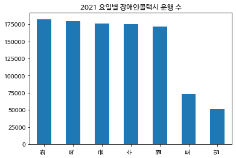

```python
## 2021 요일별 장애인콜택시 운행 수
plt.title("2021 요일별 장애인콜택시 운행 수")
df21['week'].value_counts().plot(kind='bar')
```

- 요일별 장애인 콜택시 평균 운행 건수

```python
## 요일별 장애인콜택시 평균 운행 건수
df20_week_count = df20['date'].value_counts().sort_index().rename_axis('date').reset_index(name='counts')
df21_week_count = df21['date'].value_counts().sort_index().rename_axis('date').reset_index(name='counts')
days = ['월', '화', '수', '목', '금','토','일']
df20_week_count['week'] = df20_week_count['date'].apply(lambda x:  days[pd.Timestamp(x).weekday()])
df21_week_count['week'] = df21_week_count['date'].apply(lambda x:  days[pd.Timestamp(x).weekday()])
```

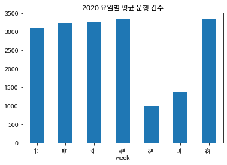

```python
# df20_week_count
plt.title("2020 요일별 평균 운행 건수")
df20_week_count['counts'].groupby(df20_week_count['week']).mean().plot(kind='bar')
```

[figure not shown]

```python
# df21_week_count
plt.title("2021 요일별 평균 운행 건수")
df21_week_count['counts'].groupby(df21_week_count['week']).mean().plot(kind='bar')
```

- 장애인 콜택시 차량 대수

```python
## (이 기간 동안 운영한) 장애인콜택시 차량 대수
df20['no'].nunique(), df21['no'].nunique()
```

```
(778, 747)
```

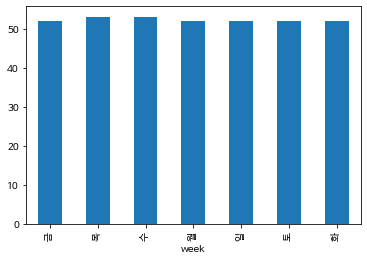

```python
# 2020 요일별 차량 대수
df20['no'].groupby(df20_week_count['week']).count().plot(kind='bar')
```

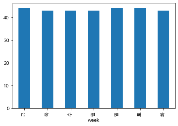

```python
# 2021 요일별 차량 대수
df21['no'].groupby(df21_week_count['week']).count().plot(kind='bar')
```

#### 2) 출발지 분석(구/동 별 빈도)

- 출발지 자치구 순위 알아보기

```python
# 2020 출발지 자치구 (빈도수가 높은 순서대로)
df20['startpos1'].value_counts().sort_values(ascending=False)
start20 = df20['startpos1'].value_counts().sort_values(ascending=False)
start20 = pd.DataFrame(start20) # 시리즈 -> 데이터프레임

start20
```

|  | startpos1 |
| --- | --- |
| 노원구 | 98762 |
| 강서구 | 65703 |
| 은평구 | 54598 |
| 서대문구 | 50174 |
| 강동구 | 48587 |
| 마포구 | 45441 |
| 송파구 | 45239 |
| 강남구 | 43316 |
| 중랑구 | 42435 |
| 동대문구 | 39644 |
| 영등포구 | 37768 |
| 강북구 | 37271 |
| 관악구 | 36840 |
| 도봉구 | 36241 |
| 성북구 | 34976 |
| 종로구 | 34414 |
| 양천구 | 32247 |
| 구로구 | 31935 |
| 동작구 | 28306 |
| 서초구 | 27918 |
| 성동구 | 25170 |
| 광진구 | 24805 |
| 용산구 | 17152 |
| 중구 | 16825 |
| 금천구 | 14480 |
| 김포시 | 893 |
| 남양주시 | 593 |
| 고양시덕양구 | 372 |
| 고양시일산동구 | 359 |
| 하남시 | 348 |
| 의정부시 | 283 |
| 부천시오정구 | 267 |
| 부천시원미구 | 247 |
| 양주시 | 238 |
| 광명시 | 209 |
| 성남시수정구 | 178 |
| 구리시 | 178 |
| 성남시분당구 | 169 |
| 고양시일산서구 | 148 |
| 성남시중원구 | 122 |
| 부천시소사구 | 101 |
| 과천시 | 79 |
| 안양시만안구 | 74 |
| 안양시동안구 | 71 |
| 부평구 | 42 |
| 수원시팔달구 | 14 |
| 용인시수지구 | 11 |
| 남동구 | 5 |
| 광주시 | 2 |
| 수원시권선구 | 2 |
| 파주시 | 1 |
| 용인시기흥구 | 1 |

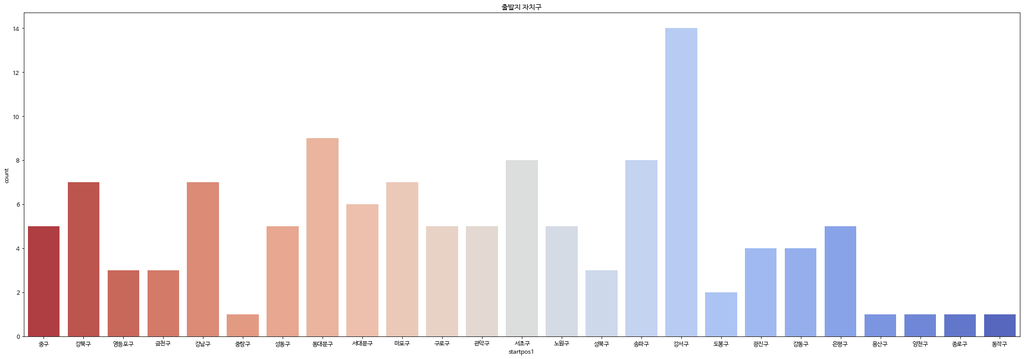

```python
# 2020 출발지 자치구 시각화
plt.figure(figsize=(30, 10))

sns.countplot(x='startpos1', data=df20[:120], palette='coolwarm_r') # 서울만
plt.title("출발지 자치구")
plt.show()
```

```python
# 2021 출발지 자치구 (빈도수가 높은 순서대로)
df21['startpos1'].value_counts().sort_values(ascending=False)
start21 = df21['startpos1'].value_counts().sort_values(ascending=False)
start21 = pd.DataFrame(start21) # 시리즈 -> 데이터프레임

start21
```

|  | startpos1 |
| --- | --- |
| 노원구 | 107038 |
| 강서구 | 69142 |
| 서대문구 | 58700 |
| 은평구 | 58386 |
| 강동구 | 55854 |
| 마포구 | 50489 |
| 송파구 | 45206 |
| 강남구 | 44643 |
| 중랑구 | 44265 |
| 동대문구 | 38652 |
| 강북구 | 36564 |
| 관악구 | 36187 |
| 도봉구 | 36134 |
| 영등포구 | 35192 |
| 성북구 | 33373 |
| 종로구 | 32991 |
| 양천구 | 32933 |
| 구로구 | 32465 |
| 동작구 | 28673 |
| 광진구 | 26924 |
| 서초구 | 26888 |
| 성동구 | 24520 |
| 용산구 | 17148 |
| 중구 | 16244 |
| 금천구 | 15786 |
| 남양주시 | 884 |
| 김포시 | 838 |
| 하남시 | 430 |
| 고양시덕양구 | 333 |
| 고양시일산동구 | 332 |
| 양주시 | 307 |
| 의정부시 | 262 |
| 성남시수정구 | 245 |
| 광명시 | 242 |
| 부천시원미구 | 229 |
| 구리시 | 208 |
| 성남시분당구 | 168 |
| 부천시오정구 | 148 |
| 부천시소사구 | 102 |
| 성남시중원구 | 102 |
| 안양시만안구 | 80 |
| 고양시일산서구 | 80 |
| 안양시동안구 | 51 |
| 과천시 | 46 |
| 부평구 | 20 |
| 수원시팔달구 | 7 |
| 용인시수지구 | 6 |
| 수원시권선구 | 3 |
| 남동구 | 2 |
| 서구 | 2 |
| 계양구 | 2 |
| 양평군 | 1 |
| 시흥시 | 1 |
| 군포시 | 1 |

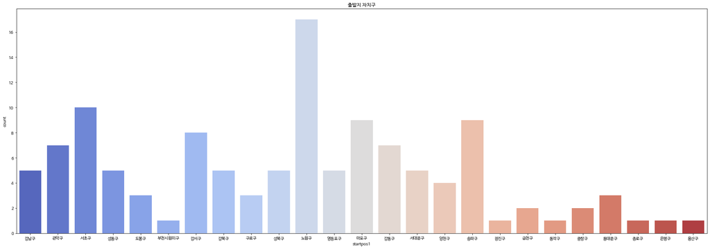

```python
# 2021 출발지 자치구
plt.figure(figsize=(30, 10))

sns.countplot(x='startpos1', data=df21[:120], palette='coolwarm') # 서울만
plt.title("출발지 자치구")
plt.show()
```

- 출발지가 많은 자치구 중에서도 동별 빈도

```python
# 2020 구 별 출발지가 가장 많은 동&빈도
df20[['startpos1','startpos2']].groupby(['startpos1']).describe()
## 유의미한 데이터 : top, freq
## top : 최빈값
## freq : 최빈값의 빈도
```

| startpos1 | startpos2 count | startpos2 unique | startpos2 top | startpos2 freq |
| --- | --- | --- | --- | --- |
| 강남구 | 43316 | 22 | 세곡동 | 6975 |
| 강동구 | 48587 | 18 | 둔촌제2동 | 6715 |
| 강북구 | 37271 | 13 | 인수동 | 6398 |
| 강서구 | 65703 | 20 | 등촌제3동 | 9113 |
| 고양시덕양구 | 372 | 19 | 흥도동 | 92 |
| 고양시일산동구 | 359 | 11 | 장항2동 | 124 |
| 고양시일산서구 | 148 | 8 | 송산동 | 39 |
| 과천시 | 79 | 5 | 문원동 | 48 |
| 관악구 | 36840 | 21 | 보라매동 | 6563 |
| 광명시 | 209 | 17 | 소하2동 | 41 |
| 광주시 | 2 | 1 | 초월읍 | 2 |
| 광진구 | 24805 | 15 | 화양동 | 3597 |
| 구로구 | 31935 | 15 | 구로제5동 | 5401 |
| 구리시 | 178 | 8 | 교문1동 | 69 |
| 금천구 | 14480 | 10 | 독산제1동 | 3769 |
| 김포시 | 893 | 10 | 대곶면 | 483 |
| 남동구 | 5 | 1 | 구월1동 | 5 |
| 남양주시 | 593 | 15 | 조안면 | 237 |
| 노원구 | 98762 | 19 | 하계1동 | 21137 |
| 도봉구 | 36241 | 14 | 도봉제2동 | 9237 |
| 동대문구 | 39644 | 22 | 휘경제2동 | 6307 |
| 동작구 | 28306 | 15 | 신대방제2동 | 8494 |
| 마포구 | 45441 | 16 | 성산제2동 | 13384 |
| 부천시소사구 | 101 | 9 | 송내1동 | 61 |
| 부천시오정구 | 267 | 7 | 원종1동 | 159 |
| 부천시원미구 | 247 | 19 | 춘의동 | 73 |
| 부평구 | 42 | 1 | 일신동 | 42 |
| 서대문구 | 50174 | 14 | 신촌동 | 20130 |
| 서초구 | 27918 | 18 | 양재1동 | 3944 |
| 성남시분당구 | 169 | 16 | 구미동 | 36 |
| 성남시수정구 | 178 | 13 | 신촌동 | 95 |
| 성남시중원구 | 122 | 9 | 은행2동 | 48 |
| 성동구 | 25170 | 17 | 왕십리도선동 | 4839 |
| 성북구 | 34976 | 20 | 길음제1동 | 5741 |
| 송파구 | 45239 | 26 | 풍납2동 | 7462 |
| 수원시권선구 | 2 | 1 | 권선1동 | 2 |
| 수원시팔달구 | 14 | 2 | 행궁동 | 13 |
| 안양시동안구 | 71 | 13 | 부림동 | 12 |
| 안양시만안구 | 74 | 10 | 안양5동 | 18 |
| 양주시 | 238 | 9 | 회천2동 | 63 |
| 양천구 | 32247 | 18 | 신정3동 | 6356 |
| 영등포구 | 37768 | 18 | 여의동 | 8124 |
| 용산구 | 17152 | 16 | 한강로동 | 2384 |
| 용인시기흥구 | 1 | 1 | 동백동 | 1 |
| 용인시수지구 | 11 | 1 | 동천동 | 11 |
| 은평구 | 54598 | 16 | 역촌동 | 14318 |
| 의정부시 | 283 | 15 | 송산2동 | 56 |
| 종로구 | 34414 | 18 | 이화동 | 10494 |
| 중구 | 16825 | 16 | 회현동 | 3049 |
| 중랑구 | 42435 | 16 | 신내1동 | 8646 |
| 파주시 | 1 | 1 | 조리읍 | 1 |
| 하남시 | 348 | 10 | 풍산동 | 123 |

```python
# 2021 구 별 출발지가 가장 많은 동&빈도
df21[['startpos1','startpos2']].groupby(['startpos1']).describe()
## 유의미한 데이터 : top, freq
## top : 최빈값
## freq : 최빈값의 빈도
```

| startpos1 | startpos2 count | startpos2 unique | startpos2 top | startpos2 freq |
| --- | --- | --- | --- | --- |
| 강남구 | 44643 | 22 | 수서동 | 7369 |
| 강동구 | 55854 | 18 | 상일동 | 8184 |
| 강북구 | 36564 | 13 | 번제3동 | 6186 |
| 강서구 | 69142 | 20 | 등촌제3동 | 9184 |
| 계양구 | 2 | 1 | 계양1동 | 2 |
| 고양시덕양구 | 333 | 18 | 고양동 | 107 |
| 고양시일산동구 | 332 | 10 | 장항2동 | 88 |
| 고양시일산서구 | 80 | 9 | 대화동 | 29 |
| 과천시 | 46 | 6 | 문원동 | 19 |
| 관악구 | 36187 | 21 | 보라매동 | 6075 |
| 광명시 | 242 | 16 | 소하1동 | 47 |
| 광진구 | 26924 | 15 | 구의제2동 | 4077 |
| 구로구 | 32465 | 15 | 구로제5동 | 5373 |
| 구리시 | 208 | 8 | 동구동 | 67 |
| 군포시 | 1 | 1 | 군포1동 | 1 |
| 금천구 | 15786 | 10 | 독산제1동 | 4201 |
| 김포시 | 838 | 10 | 대곶면 | 499 |
| 남동구 | 2 | 1 | 구월1동 | 2 |
| 남양주시 | 884 | 15 | 조안면 | 336 |
| 노원구 | 107038 | 19 | 하계1동 | 25599 |
| 도봉구 | 36134 | 14 | 도봉제2동 | 9288 |
| 동대문구 | 38652 | 22 | 휘경제2동 | 5562 |
| 동작구 | 28673 | 15 | 신대방제2동 | 8750 |
| 마포구 | 50489 | 16 | 성산제2동 | 15606 |
| 부천시소사구 | 102 | 8 | 송내1동 | 47 |
| 부천시오정구 | 148 | 7 | 원종1동 | 98 |
| 부천시원미구 | 229 | 19 | 역곡1동 | 49 |
| 부평구 | 20 | 1 | 일신동 | 20 |
| 서구 | 2 | 2 | 석남2동 | 1 |
| 서대문구 | 58700 | 14 | 신촌동 | 21986 |
| 서초구 | 26888 | 18 | 양재1동 | 4001 |
| 성남시분당구 | 168 | 18 | 구미동 | 40 |
| 성남시수정구 | 245 | 15 | 신촌동 | 125 |
| 성남시중원구 | 102 | 8 | 은행2동 | 41 |
| 성동구 | 24520 | 17 | 왕십리도선동 | 5400 |
| 성북구 | 33373 | 20 | 길음제1동 | 5085 |
| 송파구 | 45206 | 26 | 풍납2동 | 7919 |
| 수원시권선구 | 3 | 1 | 권선1동 | 3 |
| 수원시팔달구 | 7 | 2 | 행궁동 | 5 |
| 시흥시 | 1 | 1 | 정왕1동 | 1 |
| 안양시동안구 | 51 | 13 | 비산1동 | 10 |
| 안양시만안구 | 80 | 13 | 안양1동 | 19 |
| 양주시 | 307 | 11 | 장흥면 | 63 |
| 양천구 | 32933 | 18 | 신정3동 | 6123 |
| 양평군 | 1 | 1 | 양평읍 | 1 |
| 영등포구 | 35192 | 18 | 여의동 | 7516 |
| 용산구 | 17148 | 16 | 한강로동 | 2347 |
| 용인시수지구 | 6 | 1 | 동천동 | 6 |
| 은평구 | 58386 | 16 | 역촌동 | 13663 |
| 의정부시 | 262 | 15 | 송산1동 | 31 |
| 종로구 | 32991 | 18 | 이화동 | 9445 |
| 중구 | 16244 | 17 | 회현동 | 2753 |
| 중랑구 | 44265 | 16 | 신내1동 | 9097 |
| 하남시 | 430 | 10 | 감북동 | 136 |

#### 3) 목적지 분석(구/동 별 빈도)

- 목적지 자치구 순위 알아보기

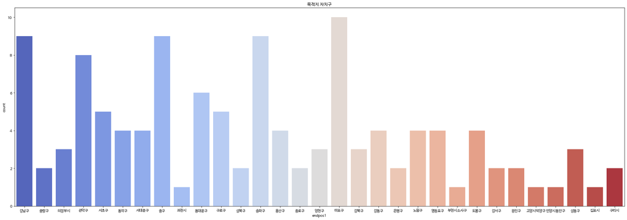

```python
## 2020 목적지 자치구
plt.figure(figsize=(30, 10))
sns.countplot(x='endpos1', data=df20[:120], palette='coolwarm')
plt.title("목적지 자치구")
plt.show()
```

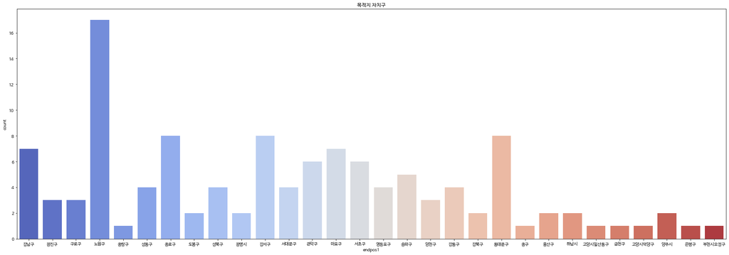

```python
## 2021 목적지 자치구
plt.figure(figsize=(30, 10))
sns.countplot(x='endpos1', data=df21[:120], palette='coolwarm')
plt.title("목적지 자치구")
plt.show()
```

- 목적지가 많은 자치구 중에서도 동별 빈도

```python
# 2020 구 별 목적지가 가장 많은 동&빈도
df20[['endpos1','endpos2']].groupby(['endpos1']).describe()
## 유의미한 데이터 : top, freq
## top : 최빈값
## freq : 최빈값의 빈도
```

| endpos1 | endpos2 count | endpos2 unique | endpos2 top | endpos2 freq |
| --- | --- | --- | --- | --- |
| 강남구 | 39724 | 22 | 세곡동 | 6216 |
| 강동구 | 43043 | 18 | 상일동 | 6102 |
| 강북구 | 36527 | 13 | 인수동 | 6243 |
| 강서구 | 60259 | 20 | 가양제2동 | 7961 |
| 계양구 | 13 | 6 | 작전서운동 | 4 |
| ... | ... | ... | ... | ... |
| 중랑구 | 39621 | 16 | 신내1동 | 8591 |
| 파주시 | 63 | 4 | 금촌2동 | 41 |
| 평택시 | 1 | 1 | 비전2동 | 1 |
| 하남시 | 3637 | 10 | 풍산동 | 1908 |
| 화성시 | 5 | 2 | 동탄1동 | 4 |

67 rows × 4 columns

```python
# 2021 구 별 목적지가 가장 많은 동&빈도
df21[['endpos1','endpos2']].groupby(['endpos1']).describe()
## 유의미한 데이터 : top, freq
## top : 최빈값
## freq : 최빈값의 빈도
```

| endpos1 | endpos2 count | endpos2 unique | endpos2 top | endpos2 freq |
| --- | --- | --- | --- | --- |
| 가평군 | 1 | 1 | 청평면 | 1 |
| 강남구 | 40720 | 22 | 세곡동 | 6329 |
| 강동구 | 48831 | 18 | 상일동 | 6964 |
| 강북구 | 35802 | 13 | 번제3동 | 5819 |
| 강서구 | 64148 | 20 | 등촌제3동 | 7943 |
| ... | ... | ... | ... | ... |
| 중랑구 | 42150 | 16 | 신내1동 | 9546 |
| 파주시 | 241 | 3 | 금촌2동 | 204 |
| 평택시 | 1 | 1 | 고덕면 | 1 |
| 하남시 | 5863 | 10 | 풍산동 | 3043 |
| 화성시 | 2 | 1 | 동탄1동 | 2 |

70 rows × 4 columns

#### 4) 시간대 분석

- 주된 이용시간 분석(신청/배차/승차 시간)

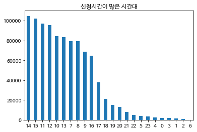

```python
## 2020 신청시간이 많은 시간대 (receipttime_time / receipttime_hour)
plt.title("신청시간이 많은 시간대")
df20['receipttime_hour'].value_counts().plot(kind='bar', rot=0)
```

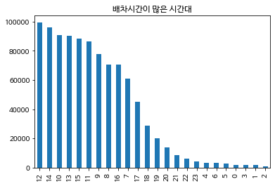

```python
## 2020 배차시간이 많은 시간대 (settime)
plt.title("배차시간이 많은 시간대")
df20['settime_hour'].value_counts().plot(kind='bar')
```

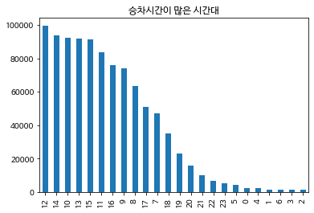

```python
## 2020 승차시간이 많은 시간대 (ridetime)
plt.title("승차시간이 많은 시간대")
df20['ridetime_hour'].value_counts().plot(kind='bar')
```

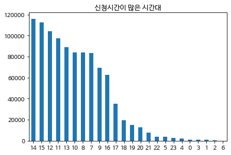

```python
## 2021 신청시간이 많은 시간대 (receipttime_time / receipttime_hour)
plt.title("신청시간이 많은 시간대")
df21['receipttime_hour'].value_counts().plot(kind='bar', rot=0)
```

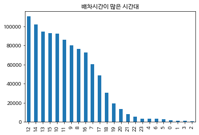

```python
## 2021 배차시간이 많은 시간대 (settime)
plt.title("배차시간이 많은 시간대")
df21['settime_hour'].value_counts().plot(kind='bar')
```

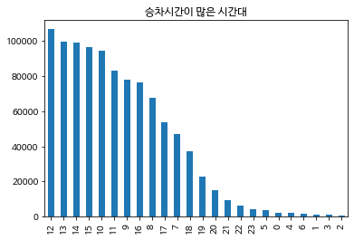

```python
## 2021 승차시간이 많은 시간대 (ridetime)
plt.title("승차시간이 많은 시간대")
df21['ridetime_hour'].value_counts().plot(kind='bar')
```

- 일별 배차 대기시간 컬럼 추가

```python
## 2020 배차일시 - 예정일시: 승객이 택시 배차를 기다리는 시간 (배차 대기시간) => 배차 소요시간
df20['wait_for_set']=df20['settime_time'] - df20['receipttime_time']
## 2021 배차일시 - 예정일시: 승객이 택시 배차를 기다리는 시간 (배차 대기시간)
df21['wait_for_set']=df21['settime_time'] - df21['receipttime_time']

## 2020 승차일시 - 배차일시: 배차후 실제 승차를 기다리는 시간 (승차 대기시간) => 배차 후 승차 소요시간
df20['wait_for_ride']=df20['ridetime_time']-df20['settime_time']
## 2021 승차일시 - 배차일시: 배차후 실제 승차를 기다리는 시간 (승차 대기시간) -> 차고지 입지 선정과 관련
df21['wait_for_ride']=df21['ridetime_time']-df21['settime_time']

## 2020 승객이 콜을하고 승차할때까지 총 걸린 대기 시간
df20['total_wait']=df20['ridetime_time'] - df20['receipttime_time']
## 2021 승객이 콜을하고 승차할때까지 총 걸린 대기 시간
df21['total_wait']=df21['ridetime_time'] - df21['receipttime_time']
```

- 요일별 평균 대기 시간

```python
## 2020 요일 별 평균 배차 대기시간
df20[['week','wait_for_set']].groupby(['week']).describe()
# [week, mean]: 요일 별 평균 배차 대기시간
```

| week | wait_for_set count | wait_for_set mean | wait_for_set std | wait_for_set min | wait_for_set 25% | wait_for_set 50% | wait_for_set 75% | wait_for_set max |
| --- | --- | --- | --- | --- | --- | --- | --- | --- |
| 금 | 161174 | 0 days 00:14:46.457226384 | 0 days 00:21:21.160376478 | -1 days +20:42:29 | 0 days 00:03:09.999999 | 0 days 00:08:20 | 0 days 00:18:06 | 0 days 04:27:26 |
| 목 | 171284 | 0 days 00:15:21.252691476 | 0 days 00:21:11.430793531 | -1 days +19:44:08 | 0 days 00:03:20 | 0 days 00:08:37 | 0 days 00:20:15.000001 | 0 days 04:53:38 |
| 수 | 172424 | 0 days 00:15:16.370870676 | 0 days 00:21:18.648983122 | -1 days +00:01:22 | 0 days 00:03:19 | 0 days 00:08:35.999999 | 0 days 00:20:05 | 0 days 04:44:56 |
| 월 | 173581 | 0 days 00:14:52.207234700 | 0 days 00:19:49.368068323 | -1 days +20:19:16 | 0 days 00:03:15.000001 | 0 days 00:08:29 | 0 days 00:19:37 | 0 days 04:10:24 |
| 일 | 51641 | 0 days 00:07:56.084893806 | 0 days 00:12:45.142892426 | -1 days +00:00:58 | 0 days 00:02:59.000001 | 0 days 00:06:23 | 0 days 00:09:10 | 0 days 02:30:59 |
| 토 | 71324 | 0 days 00:09:23.434720471 | 0 days 00:14:00.780480232 | -1 days +20:13:43 | 0 days 00:02:58.000001 | 0 days 00:07:04.000000500 | 0 days 00:10:42 | 0 days 03:46:50 |
| 화 | 173842 | 0 days 00:14:28.978365451 | 0 days 00:19:49.833154726 | -1 days +20:32:05 | 0 days 00:03:15 | 0 days 00:08:30.999999 | 0 days 00:19:07 | 0 days 04:30:31 |

```python
## 2020 요일 별 평균 승차 대기시간
df20[['week','wait_for_ride']].groupby(['week']).describe()
# [week, mean]: 요일 별 평균 승차 대기시간
```

| week | wait_for_ride count | wait_for_ride mean | wait_for_ride std | wait_for_ride min | wait_for_ride 25% | wait_for_ride 50% | wait_for_ride 75% | wait_for_ride max |
| --- | --- | --- | --- | --- | --- | --- | --- | --- |
| 금 | 161174 | 0 days 00:19:35.217535088 | 0 days 00:08:52.396595383 | -1 days +22:33:29.999999 | 0 days 00:13:22 | 0 days 00:18:30 | 0 days 00:24:33 | 0 days 02:46:16.000001 |
| 목 | 171284 | 0 days 00:19:29.098362951 | 0 days 00:08:51.068268694 | -1 days +22:56:08.000001 | 0 days 00:13:18 | 0 days 00:18:25 | 0 days 00:24:26.999999 | 0 days 02:24:48 |
| 수 | 172424 | 0 days 00:19:24.165997773 | 0 days 00:08:38.047297498 | -1 days +22:35:40.999999 | 0 days 00:13:21 | 0 days 00:18:24 | 0 days 00:24:18 | 0 days 02:15:54.999999 |
| 월 | 173581 | 0 days 00:19:13.778449252 | 0 days 00:08:37.461166303 | -1 days +23:19:08 | 0 days 00:13:12 | 0 days 00:18:12 | 0 days 00:24:03 | 0 days 03:01:43.000001 |
| 일 | 51641 | 0 days 00:18:08.012858001 | 0 days 00:08:04.108164348 | -1 days +23:57:49 | 0 days 00:12:30 | 0 days 00:17:08 | 0 days 00:22:41.999999 | 0 days 02:28:25 |
| 토 | 71324 | 0 days 00:20:15.798090405 | 0 days 00:09:21.150622226 | -1 days +23:31:50 | 0 days 00:13:47.999999 | 0 days 00:19:09.000001 | 0 days 00:25:27.999999 | 0 days 08:12:48 |
| 화 | 173842 | 0 days 00:19:22.300261156 | 0 days 00:08:37.372128196 | -1 days +23:06:10 | 0 days 00:13:17.999999 | 0 days 00:18:24 | 0 days 00:24:17.999999 | 0 days 02:14:03.000001 |

- 시간대별 평균 대기 시간

[figure not shown]

```python
## 2020 시간대 별 대기시간
df20_time = df20[['receipttime_hour','wait_for_ride']].groupby(['receipttime_hour']).describe().reset_index()
plt.title("시간대 별 대기시간 (분단위)")
plt.plot(df20_time['receipttime_hour'], df20_time['wait_for_ride']['mean'].dt.total_seconds()/60)
plt.show()
```

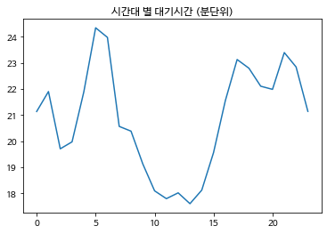

```python
## 2021 시간대 별 대기시간
df21_time = df21[['receipttime_hour','wait_for_ride']].groupby(['receipttime_hour']).describe().reset_index()
plt.title("시간대 별 대기시간 (분단위)")
plt.plot(df21_time['receipttime_hour'], df21_time['wait_for_ride']['mean'].dt.total_seconds()/60)
plt.show()
```

### 4) 데이터 분석

#### 4-1) 상관관계 분석

##### 4-1-1) 자치구 상관관계 분석

```python
import pandas as pd
import numpy as np
import seaborn as sns
import matplotlib.pyplot as plt
```

```python
# 데이터 불러오기
df_dis = pd.read_excel('./data/여러시설데이터/서울시 장애인거주현황.xlsx')
df_job = pd.read_excel('./data/여러시설데이터/서울특별시 사회복지시설(장애인직업재활시설) 목록.xlsx')
df_re = pd.read_excel('./data/여러시설데이터/서울특별시 사회복지시설(장애인지역사회재활시설) 목록.xlsx')
df_hou = pd.read_excel('./data/여러시설데이터/서울특별시 사회복지시설(장애인거주시설) 목록.xlsx')
df_hos = pd.read_excel('./data/여러시설데이터/서울특별시 의료기관 통계.xls')
df_sch = pd.read_excel('./data/여러시설데이터/서울특별시 특수학교 통계.xls')
```

- 데이터 탐색

```python
# 자치구 별 2021 출발지 빈도
df21_start = df21['startpos1'].value_counts(ascending=False).rename_axis('자치구').reset_index(name='출발지 빈도')
df21_start
```

|  | 자치구 | 출발지 빈도 |
| --- | --- | --- |
| 0 | 노원구 | 107038 |
| 1 | 강서구 | 69142 |
| 2 | 서대문구 | 58700 |
| 3 | 은평구 | 58386 |
| 4 | 강동구 | 55854 |
| 5 | 마포구 | 50489 |
| 6 | 송파구 | 45206 |
| 7 | 강남구 | 44643 |
| 8 | 중랑구 | 44265 |
| 9 | 동대문구 | 38652 |
| 10 | 강북구 | 36564 |
| 11 | 관악구 | 36187 |
| 12 | 도봉구 | 36134 |
| 13 | 영등포구 | 35192 |
| 14 | 성북구 | 33373 |
| 15 | 종로구 | 32991 |
| 16 | 양천구 | 32933 |
| 17 | 구로구 | 32465 |
| 18 | 동작구 | 28673 |
| 19 | 광진구 | 26924 |
| 20 | 서초구 | 26888 |
| 21 | 성동구 | 24520 |
| 22 | 용산구 | 17148 |
| 23 | 중구 | 16244 |
| 24 | 금천구 | 15786 |
| 25 | 남양주시 | 884 |
| 26 | 김포시 | 838 |
| 27 | 하남시 | 430 |
| 28 | 고양시덕양구 | 333 |
| 29 | 고양시일산동구 | 332 |
| 30 | 양주시 | 307 |
| 31 | 의정부시 | 262 |
| 32 | 성남시수정구 | 245 |
| 33 | 광명시 | 242 |
| 34 | 부천시원미구 | 229 |
| 35 | 구리시 | 208 |
| 36 | 성남시분당구 | 168 |
| 37 | 부천시오정구 | 148 |
| 38 | 부천시소사구 | 102 |
| 39 | 성남시중원구 | 102 |
| 40 | 고양시일산서구 | 80 |
| 41 | 안양시만안구 | 80 |
| 42 | 안양시동안구 | 51 |
| 43 | 과천시 | 46 |
| 44 | 부평구 | 20 |
| 45 | 수원시팔달구 | 7 |
| 46 | 용인시수지구 | 6 |
| 47 | 수원시권선구 | 3 |
| 48 | 남동구 | 2 |
| 49 | 서구 | 2 |
| 50 | 계양구 | 2 |
| 51 | 양평군 | 1 |
| 52 | 시흥시 | 1 |
| 53 | 군포시 | 1 |

```python
# 자치구 별 2021 목적지 빈도
df21_end = df21['endpos1'].value_counts(ascending=False).rename_axis('자치구').reset_index(name='목적지 빈도')
df21_end
```

|  | 자치구 | 목적지 빈도 |
| --- | --- | --- |
| 0 | 노원구 | 99063 |
| 1 | 강서구 | 64148 |
| 2 | 서대문구 | 54874 |
| 3 | 은평구 | 54710 |
| 4 | 강동구 | 48831 |
| ... | ... | ... |
| 65 | 가평군 | 1 |
| 66 | 오산시 | 1 |
| 67 | 평택시 | 1 |
| 68 | 강화군 | 1 |
| 69 | 의왕시 | 1 |

70 rows × 2 columns

```python
# 자치구 별 장애인거주현황
df_dis.head()
```

|  | 자치구 | 장애인거주현황 |
| --- | --- | --- |
| 0 | 종로구 | 6015 |
| 1 | 중구 | 5700 |
| 2 | 용산구 | 7960 |
| 3 | 성동구 | 11412 |
| 4 | 광진구 | 12353 |

```python
# 시군구 별 직업재활시설 개수 (자치구 별 직업재활시설 개수)
df_job = df_job['시군구명'].value_counts(ascending=False).rename_axis('자치구').reset_index(name='장애인직업재활시설 개수')
df_job
```

|  | 자치구 | 장애인직업재활시설 개수 |
| --- | --- | --- |
| 0 | 송파구 | 13 |
| 1 | 강동구 | 12 |
| 2 | 강서구 | 12 |
| 3 | 노원구 | 9 |
| 4 | 강남구 | 9 |
| 5 | 구로구 | 8 |
| 6 | 금천구 | 7 |
| 7 | 중랑구 | 7 |
| 8 | 은평구 | 7 |
| 9 | 서초구 | 6 |
| 10 | 관악구 | 5 |
| 11 | 동작구 | 4 |
| 12 | 강북구 | 4 |
| 13 | 마포구 | 4 |
| 14 | 동대문구 | 4 |
| 15 | 성동구 | 4 |
| 16 | 광진구 | 4 |
| 17 | 서대문구 | 3 |
| 18 | 종로구 | 3 |
| 19 | 도봉구 | 3 |
| 20 | 영등포구 | 3 |
| 21 | 양천구 | 3 |
| 22 | 성북구 | 2 |
| 23 | 용산구 | 1 |
| 24 | 서울특별시 | 1 |
| 25 | 중구 | 1 |

```python
# 시군구 별 지역사회재활시설 개수 (자치구 별 지역사회재활시설 개수)
df_re = df_re['시군구명'].value_counts(ascending=False).rename_axis('자치구').reset_index(name='장애인지역사회재활시설 개수')
df_re
```

|  | 자치구 | 장애인지역사회재활시설 개수 |
| --- | --- | --- |
| 0 | 노원구 | 27 |
| 1 | 송파구 | 17 |
| 2 | 강서구 | 17 |
| 3 | 강남구 | 17 |
| 4 | 서초구 | 13 |
| 5 | 강동구 | 13 |
| 6 | 마포구 | 10 |
| 7 | 은평구 | 10 |
| 8 | 광진구 | 9 |
| 9 | 동작구 | 9 |
| 10 | 관악구 | 9 |
| 11 | 중구 | 8 |
| 12 | 구로구 | 8 |
| 13 | 서대문구 | 8 |
| 14 | 강북구 | 8 |
| 15 | 도봉구 | 8 |
| 16 | 영등포구 | 7 |
| 17 | 양천구 | 7 |
| 18 | 용산구 | 6 |
| 19 | 금천구 | 6 |
| 20 | 성동구 | 4 |
| 21 | 종로구 | 4 |
| 22 | 동대문구 | 4 |
| 23 | 성북구 | 3 |
| 24 | 중랑구 | 3 |

```python
# 시군구 별 장애인거주시설 개수 (자치구 별 장애인거주시설 개수)
df_hou = df_hou['시군구명'].value_counts(ascending=False).rename_axis('자치구').reset_index(name='장애인거주시설 개수')
df_hou = df_hou.drop(index=25, axis=0) # 서울특별시 행 제거
df_hou
```

|  | 자치구 | 장애인거주시설 개수 |
| --- | --- | --- |
| 0 | 강서구 | 30 |
| 1 | 강남구 | 24 |
| 2 | 노원구 | 23 |
| 3 | 송파구 | 22 |
| 4 | 강동구 | 19 |
| 5 | 강북구 | 18 |
| 6 | 은평구 | 16 |
| 7 | 구로구 | 13 |
| 8 | 서초구 | 12 |
| 9 | 도봉구 | 12 |
| 10 | 양천구 | 11 |
| 11 | 관악구 | 9 |
| 12 | 금천구 | 8 |
| 13 | 마포구 | 8 |
| 14 | 서대문구 | 7 |
| 15 | 영등포구 | 7 |
| 16 | 동작구 | 7 |
| 17 | 종로구 | 5 |
| 18 | 성북구 | 4 |
| 19 | 용산구 | 4 |
| 20 | 성동구 | 4 |
| 21 | 중랑구 | 3 |
| 22 | 중구 | 2 |
| 23 | 동대문구 | 1 |
| 24 | 광진구 | 1 |

```python
# 자치구 별 의료기관 수
df_hos
```

|  | 자치구 | 종합병원수 | 병원수 |
| --- | --- | --- | --- |
| 0 | 종로구 | 4 | 2 |
| 1 | 중구 | 2 | 4 |
| 2 | 용산구 | 1 | 2 |
| 3 | 성동구 | 1 | 5 |
| 4 | 광진구 | 2 | 5 |
| 5 | 동대문구 | 4 | 13 |
| 6 | 중랑구 | 3 | 13 |
| 7 | 성북구 | 1 | 6 |
| 8 | 강북구 | 1 | 10 |
| 9 | 도봉구 | 1 | 8 |
| 10 | 노원구 | 3 | 6 |
| 11 | 은평구 | 2 | 10 |
| 12 | 서대문구 | 2 | 5 |
| 13 | 마포구 | 0 | 3 |
| 14 | 양천구 | 3 | 5 |
| 15 | 강서구 | 4 | 17 |
| 16 | 구로구 | 2 | 8 |
| 17 | 금천구 | 1 | 6 |
| 18 | 영등포구 | 7 | 8 |
| 19 | 동작구 | 2 | 5 |
| 20 | 관악구 | 1 | 11 |
| 21 | 서초구 | 1 | 13 |
| 22 | 강남구 | 3 | 32 |
| 23 | 송파구 | 2 | 17 |
| 24 | 강동구 | 3 | 14 |

```python
# 자치구 별 특수학교 학생수
df_sch
```

|  | 자치구 | 특수학교 학생수 |
| --- | --- | --- |
| 0 | 종로구 | 450 |
| 1 | 광진구 | 131 |
| 2 | 성북구 | 86 |
| 3 | 강북구 | 424 |
| 4 | 도봉구 | 117 |
| 5 | 노원구 | 446 |
| 6 | 은평구 | 240 |
| 7 | 서대문구 | 103 |
| 8 | 마포구 | 179 |
| 9 | 강서구 | 239 |
| 10 | 구로구 | 424 |
| 11 | 동작구 | 142 |
| 12 | 관악구 | 258 |
| 13 | 서초구 | 303 |
| 14 | 강남구 | 320 |
| 15 | 송파구 | 221 |
| 16 | 강동구 | 324 |

- 데이터 열 병합

```python
# 2021 출발지 빈도와 2021 목적지 빈도 열 병합 (자치구 기준)
df_merge = pd.merge(left = df21_start , right = df21_end, how = "inner", on = "자치구")
df_merge.set_index('자치구', inplace = True)

# df_merge와 '장애인거주현황' 열 병합 (자치구 기준)
df_merge = pd.merge(left = df_merge , right = df_dis, how = "inner", on = "자치구")
df_merge.set_index('자치구', inplace = True)

# df_merge와 '장애인직업재활시설 개수' 열 병합 (자치구 기준)
df_merge = pd.merge(left = df_merge , right = df_job, how = "outer", on = "자치구")
df_merge.set_index('자치구', inplace = True)

# df_merge와 '장애인지역사회재활시설 개수' 열 병합 (자치구 기준)
df_merge = pd.merge(left = df_merge , right = df_re, how = "outer", on = "자치구")
df_merge.set_index('자치구', inplace = True)

# df_merge와 '장애인거주시설 개수' 열 병합 (자치구 기준)
df_merge = pd.merge(left = df_merge , right = df_hou, how = "outer", on = "자치구")
df_merge.set_index('자치구', inplace = True)

# df_merge와 '의료기관 수' 열 병합 (자치구 기준)
df_merge = pd.merge(left = df_merge , right = df_hos, how = "inner", on = "자치구")
df_merge.set_index('자치구', inplace = True)

# df_merge와 '특수학교 학생수' 열 병합 (자치구 기준)
df_merge = pd.merge(left = df_merge , right = df_sch, how = "outer", on = "자치구")
df_merge.set_index('자치구', inplace = True)
df_merge
```

| 자치구 | 출발지 빈도 | 목적지 빈도 | 장애인거주현황 | 장애인직업재활시설 개수 | 장애인지역사회재활시설 개수 | 장애인거주시설 개수 | 종합병원수 | 병원수 | 특수학교 학생수 |
| --- | --- | --- | --- | --- | --- | --- | --- | --- | --- |
| 노원구 | 107038.0 | 99063.0 | 27312.0 | 9 | 27.0 | 23.0 | 3 | 6 | 446.0 |
| 강서구 | 69142.0 | 64148.0 | 28727.0 | 12 | 17.0 | 30.0 | 4 | 17 | 239.0 |
| 서대문구 | 58700.0 | 54874.0 | 12551.0 | 3 | 8.0 | 7.0 | 2 | 5 | 103.0 |
| 은평구 | 58386.0 | 54710.0 | 21773.0 | 7 | 10.0 | 16.0 | 2 | 10 | 240.0 |
| 강동구 | 55854.0 | 48831.0 | 18307.0 | 12 | 13.0 | 19.0 | 3 | 14 | 324.0 |
| 마포구 | 50489.0 | 45428.0 | 12951.0 | 4 | 10.0 | 8.0 | 0 | 3 | 179.0 |
| 송파구 | 45206.0 | 42714.0 | 20286.0 | 13 | 17.0 | 22.0 | 2 | 17 | 221.0 |
| 강남구 | 44643.0 | 40720.0 | 15200.0 | 9 | 17.0 | 24.0 | 3 | 32 | 320.0 |
| 중랑구 | 44265.0 | 42150.0 | 20394.0 | 7 | 3.0 | 3.0 | 3 | 13 | NaN |
| 동대문구 | 38652.0 | 36939.0 | 15701.0 | 4 | 4.0 | 1.0 | 4 | 13 | NaN |
| 강북구 | 36564.0 | 35802.0 | 17441.0 | 4 | 8.0 | 18.0 | 1 | 10 | 424.0 |
| 관악구 | 36187.0 | 34266.0 | 20265.0 | 5 | 9.0 | 9.0 | 1 | 11 | 258.0 |
| 도봉구 | 36134.0 | 34514.0 | 15436.0 | 3 | 8.0 | 12.0 | 1 | 8 | 117.0 |
| 영등포구 | 35192.0 | 35214.0 | 14539.0 | 3 | 7.0 | 7.0 | 7 | 8 | NaN |
| 성북구 | 33373.0 | 32895.0 | 17490.0 | 2 | 3.0 | 4.0 | 1 | 6 | 86.0 |
| 종로구 | 32991.0 | 32487.0 | 6015.0 | 3 | 4.0 | 5.0 | 4 | 2 | 450.0 |
| 양천구 | 32933.0 | 31770.0 | 17558.0 | 3 | 7.0 | 11.0 | 3 | 5 | NaN |
| 구로구 | 32465.0 | 29457.0 | 18280.0 | 8 | 8.0 | 13.0 | 2 | 8 | 424.0 |
| 동작구 | 28673.0 | 27681.0 | 14607.0 | 4 | 9.0 | 7.0 | 2 | 5 | 142.0 |
| 광진구 | 26924.0 | 26912.0 | 12353.0 | 4 | 9.0 | 1.0 | 2 | 5 | 131.0 |
| 서초구 | 26888.0 | 25848.0 | 10542.0 | 6 | 13.0 | 12.0 | 1 | 13 | 303.0 |
| 성동구 | 24520.0 | 24817.0 | 11412.0 | 4 | 4.0 | 4.0 | 1 | 5 | NaN |
| 용산구 | 17148.0 | 16609.0 | 7960.0 | 1 | 6.0 | 4.0 | 1 | 2 | NaN |
| 중구 | 16244.0 | 16304.0 | 5700.0 | 1 | 8.0 | 2.0 | 2 | 4 | NaN |
| 금천구 | 15786.0 | 14294.0 | 11390.0 | 7 | 6.0 | 8.0 | 1 | 6 | NaN |

- 다른 데이터들과의 변수간 관계

```python
# '재활시설 개수'와 '출발지 빈도'와 '장애인거주현황' 간 관계 (피어슨 상관계수)
cols=['출발지 빈도', '목적지 빈도', '장애인거주현황', '장애인직업재활시설 개수', '장애인지역사회재활시설 개수',	'장애인거주시설 개수', '종합병원수', '병원수', '특수학교 학생수']
corr = df_merge[cols].corr(method = 'pearson')
corr
```

|  | 출발지 빈도 | 목적지 빈도 | 장애인거주현황 | 장애인직업재활시설 개수 | 장애인지역사회재활시설 개수 | 장애인거주시설 개수 | 종합병원수 | 병원수 | 특수학교 학생수 |
| --- | --- | --- | --- | --- | --- | --- | --- | --- | --- |
| 출발지 빈도 | 1.000000 | 0.997931 | 0.744292 | 0.536377 | 0.730114 | 0.630569 | 0.250945 | 0.235489 | 0.246082 |
| 목적지 빈도 | 0.997931 | 1.000000 | 0.744962 | 0.508621 | 0.716798 | 0.613369 | 0.268926 | 0.219637 | 0.238808 |
| 장애인거주현황 | 0.744292 | 0.744962 | 1.000000 | 0.658950 | 0.550808 | 0.680620 | 0.197460 | 0.404524 | 0.121060 |
| 장애인직업재활시설 개수 | 0.536377 | 0.508621 | 0.658950 | 1.000000 | 0.665905 | 0.786937 | 0.164985 | 0.650034 | 0.337392 |
| 장애인지역사회재활시설 개수 | 0.730114 | 0.716798 | 0.550808 | 0.665905 | 1.000000 | 0.802242 | 0.095349 | 0.430086 | 0.326810 |
| 장애인거주시설 개수 | 0.630569 | 0.613369 | 0.680620 | 0.786937 | 0.802242 | 1.000000 | 0.123885 | 0.618728 | 0.413673 |
| 종합병원수 | 0.250945 | 0.268926 | 0.197460 | 0.164985 | 0.095349 | 0.123885 | 1.000000 | 0.227511 | 0.413250 |
| 병원수 | 0.235489 | 0.219637 | 0.404524 | 0.650034 | 0.430086 | 0.618728 | 0.227511 | 1.000000 | 0.156804 |
| 특수학교 학생수 | 0.246082 | 0.238808 | 0.121060 | 0.337392 | 0.326810 | 0.413673 | 0.413250 | 0.156804 | 1.000000 |

[output not shown]

[figure not shown]

```python
# 상관관계 Heatmap으로 시각화

fig = plt.figure(figsize = (16, 10))
ax = fig.gca()

sns.set(font_scale = 1.5)  # heatmap 안의 font-size 설정
heatmap = sns.heatmap(corr.values, annot = True, fmt='.2f', annot_kws={'size':15},
                      yticklabels = cols, xticklabels = cols, ax=ax, cmap = "YlGnBu")
plt.tight_layout()
plt.show()
```

[output not shown]

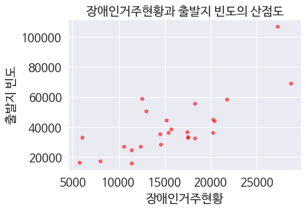

```python
# 장애인거주현황과 출발빈도의 관계 (산점도)
sns.scatterplot(data=df_merge, x='장애인거주현황', y='출발지 빈도', markers='o', color='red', alpha=0.6)
plt.title('장애인거주현황과 출발지 빈도의 산점도')
plt.show()
```

- 장애인 직업 재활 시설 개수와 출발 빈도 간의 상관관계

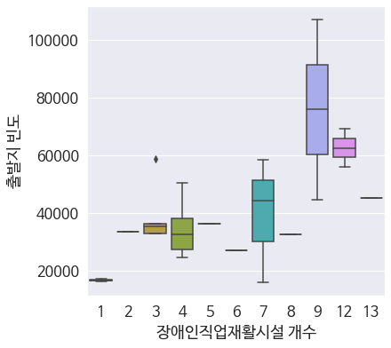

```python
# 장애인직업재활시설 개수와 출발지 빈도의 관계 (박스플롯)
fig = plt.figure(figsize = (6, 6))
sns.boxplot(x='장애인직업재활시설 개수', y='출발지 빈도', data=df_merge)
```

- pearson 상관계수가 약 0.54 이므로 '다소 높은 양의 상관관계'가 존재함.
- 산점도와 박스플롯을 봤을 때도 어느정도 양의 상관관계가 있는 것으로 보임.
- 따라서 재활시설 개수가 많은 자치구일수록 출발지 빈도수가 높은 경향이 있다고 볼 수 있음.

##### 4-1-2) 행정동 상관관계 분석

```python
# 데이터 불러오기
df_ = pd.read_excel('./data/여러시설데이터/관악구시설데이터.xlsx')
```

```python
### Person 상관계수 : 대표적으로 상관관계 분석시 사용하는 지표입니다.
### -1 에서 1 사이의 값을 가진다는 특징이 있습니다.
### 1일 때는 완전 양의 상관(perfect positive correlation), -1일 때는 완전 음의 상관관계(perfect negative correlation)관계를 보입니다.
### https://m.blog.naver.com/istech7/50153047118

cols = ['목적지총빈도수', '쇼핑', '장애인재활시설', '장애인거주시설', '음식점', '병원', '특수학교', '커피전문점', '특수학급및학교', '장애인복지시설', '다중복합시설', '음식점및카페', '장애인인구수', '병원의사수', '장애인지역사회재활시설',	'장애인거주시설',	'장애인의료재활시설',	'장애인직업재활시설']

corr = df_[cols].corr(method = 'pearson')
corr
```

|  | 목적지총빈도수 | 쇼핑 | 장애인재활시설 | 장애인거주시설 | 음식점 | 병원 | 특수학교 | 커피전문점 | 특수학급및학교 | 장애인복지시설 | 다중복합시설 | 음식점및카페 | 장애인인구수 | 병원의사수 | 장애인지역사회재활시설 | 장애인거주시설 | 장애인의료재활시설 | 장애인직업재활시설 |
| --- | --- | --- | --- | --- | --- | --- | --- | --- | --- | --- | --- | --- | --- | --- | --- | --- | --- | --- |
| 목적지총빈도수 | 1.000000 | 0.066881 | 0.365287 | 0.277292 | 0.103329 | -0.034085 | 0.579595 | 0.075883 | 0.203194 | 0.375324 | 0.470805 | 0.098944 | 0.381432 | 0.888695 | 0.115275 | 0.277292 | 0.858560 | 0.205021 |
| 쇼핑 | 0.066881 | 1.000000 | 0.312135 | 0.370200 | 0.376464 | 0.361731 | -0.222576 | -0.071250 | -0.230552 | 0.376299 | 0.388075 | 0.250341 | 0.192625 | 0.177683 | 0.322075 | 0.370200 | -0.024544 | 0.397693 |
| 장애인재활시설 | 0.365287 | 0.312135 | 1.000000 | 0.101760 | 0.356538 | 0.216905 | 0.031814 | 0.319207 | 0.031960 | 0.711056 | 0.416025 | 0.359582 | 0.168240 | 0.332760 | 0.956932 | 0.101760 | 0.175412 | 0.299183 |
| 장애인거주시설 | 0.277292 | 0.370200 | 0.101760 | 1.000000 | 0.157532 | 0.058321 | 0.084173 | -0.071815 | 0.178511 | 0.689181 | 0.104828 | 0.091451 | 0.442545 | 0.267921 | 0.034214 | 1.000000 | 0.232048 | 0.544200 |
| 음식점 | 0.103329 | 0.376464 | 0.356538 | 0.157532 | 1.000000 | 0.548631 | -0.280005 | 0.814597 | -0.287113 | 0.337817 | 0.458441 | 0.982975 | -0.266160 | 0.317554 | 0.355398 | 0.157532 | 0.014335 | 0.295702 |
| 병원 | -0.034085 | 0.361731 | 0.216905 | 0.058321 | 0.548631 | 1.000000 | -0.309239 | 0.378608 | -0.099237 | 0.163009 | 0.518195 | 0.517653 | -0.078964 | 0.165271 | 0.256729 | 0.058321 | -0.128681 | 0.095594 |
| 특수학교 | 0.579595 | -0.222576 | 0.031814 | 0.084173 | -0.280005 | -0.309239 | 1.000000 | -0.163452 | -0.002937 | 0.011647 | 0.114708 | -0.254762 | -0.040215 | 0.553374 | -0.171145 | 0.084173 | 0.689202 | -0.123738 |
| 커피전문점 | 0.075883 | -0.071250 | 0.319207 | -0.071815 | 0.814597 | 0.378608 | -0.163452 | 1.000000 | -0.242442 | 0.118249 | 0.289686 | 0.907301 | -0.435190 | 0.239048 | 0.301528 | -0.071815 | 0.069324 | -0.053577 |
| 특수학급및학교 | 0.203194 | -0.230552 | 0.031960 | 0.178511 | -0.287113 | -0.099237 | -0.002937 | -0.242442 | 1.000000 | 0.280154 | 0.012804 | -0.284937 | 0.670722 | -0.049144 | 0.020297 | 0.178511 | 0.040489 | 0.286591 |
| 장애인복지시설 | 0.375324 | 0.376299 | 0.711056 | 0.689181 | 0.337817 | 0.163009 | 0.011647 | 0.118249 | 0.280154 | 1.000000 | 0.329988 | 0.282353 | 0.452650 | 0.332925 | 0.665138 | 0.689181 | 0.176594 | 0.732464 |
| 다중복합시설 | 0.470805 | 0.388075 | 0.416025 | 0.104828 | 0.458441 | 0.518195 | 0.114708 | 0.289686 | 0.012804 | 0.329988 | 1.000000 | 0.424104 | 0.029831 | 0.560623 | 0.326377 | 0.104828 | 0.316228 | 0.337100 |
| 음식점및카페 | 0.098944 | 0.250341 | 0.359582 | 0.091451 | 0.982975 | 0.517653 | -0.254762 | 0.907301 | -0.284937 | 0.282353 | 0.424104 | 1.000000 | -0.330805 | 0.305929 | 0.353155 | 0.091451 | 0.032352 | 0.197392 |
| 장애인인구수 | 0.381432 | 0.192625 | 0.168240 | 0.442545 | -0.266160 | -0.078964 | -0.040215 | -0.435190 | 0.670722 | 0.452650 | 0.029831 | -0.330805 | 1.000000 | 0.048250 | 0.139347 | 0.442545 | 0.102921 | 0.454845 |
| 병원의사수 | 0.888695 | 0.177683 | 0.332760 | 0.267921 | 0.317554 | 0.165271 | 0.553374 | 0.239048 | -0.049144 | 0.332925 | 0.560623 | 0.305929 | 0.048250 | 1.000000 | 0.068562 | 0.267921 | 0.905710 | 0.103985 |
| 장애인지역사회재활시설 | 0.115275 | 0.322075 | 0.956932 | 0.034214 | 0.355398 | 0.256729 | -0.171145 | 0.301528 | 0.020297 | 0.665138 | 0.326377 | 0.353155 | 0.139347 | 0.068562 | 1.000000 | 0.034214 | -0.117954 | 0.326921 |
| 장애인거주시설 | 0.277292 | 0.370200 | 0.101760 | 1.000000 | 0.157532 | 0.058321 | 0.084173 | -0.071815 | 0.178511 | 0.689181 | 0.104828 | 0.091451 | 0.442545 | 0.267921 | 0.034214 | 1.000000 | 0.232048 | 0.544200 |
| 장애인의료재활시설 | 0.858560 | -0.024544 | 0.175412 | 0.232048 | 0.014335 | -0.128681 | 0.689202 | 0.069324 | 0.040489 | 0.176594 | 0.316228 | 0.032352 | 0.102921 | 0.905710 | -0.117954 | 0.232048 | 1.000000 | -0.085280 |
| 장애인직업재활시설 | 0.205021 | 0.397693 | 0.299183 | 0.544200 | 0.295702 | 0.095594 | -0.123738 | -0.053577 | 0.286591 | 0.732464 | 0.337100 | 0.197392 | 0.454845 | 0.103985 | 0.326921 | 0.544200 | -0.085280 | 1.000000 |

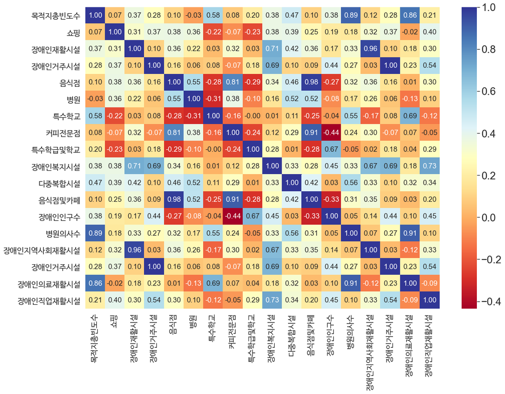

```python
### 상관관계를 직관적으로 살펴보기 위해 Heatmap 으로 돌려봅니다.
### heatmap (seaborn): 여기서는 seaborn 시각화 라이브러리를 사용해서 표현합니다.
### 시각화의 대표적인 라이브러리가 matplot(https://matplotlib.org/)과 seaborn(https://seaborn.pydata.org/)이 있습니다.

fig = plt.figure(figsize = (16, 12))
ax = fig.gca()

# https://seaborn.pydata.org/generated/seaborn.heatmap.html
sns.set(font_scale = 2)  # heatmap 안의 font-size 설정
heatmap = sns.heatmap(corr.values, annot = True, fmt='.2f', annot_kws={'size':15},
                      yticklabels = cols, xticklabels = cols, ax=ax, cmap = "RdYlBu")
plt.tight_layout()
plt.show()
```

```python
cols = ['목적지총빈도수', '음식점및카페', '특수학교', '장애인인구수', '병원의사수', '장애인지역사회재활시설']

corr = df_[cols].corr(method = 'pearson')
corr
```

|  | 목적지총빈도수 | 음식점및카페 | 특수학교 | 장애인인구수 | 병원의사수 | 장애인지역사회재활시설 |
| --- | --- | --- | --- | --- | --- | --- |
| 목적지총빈도수 | 1.000000 | 0.098944 | 0.579595 | 0.381432 | 0.888695 | 0.115275 |
| 음식점및카페 | 0.098944 | 1.000000 | -0.254762 | -0.330805 | 0.305929 | 0.353155 |
| 특수학교 | 0.579595 | -0.254762 | 1.000000 | -0.040215 | 0.553374 | -0.171145 |
| 장애인인구수 | 0.381432 | -0.330805 | -0.040215 | 1.000000 | 0.048250 | 0.139347 |
| 병원의사수 | 0.888695 | 0.305929 | 0.553374 | 0.048250 | 1.000000 | 0.068562 |
| 장애인지역사회재활시설 | 0.115275 | 0.353155 | -0.171145 | 0.139347 | 0.068562 | 1.000000 |

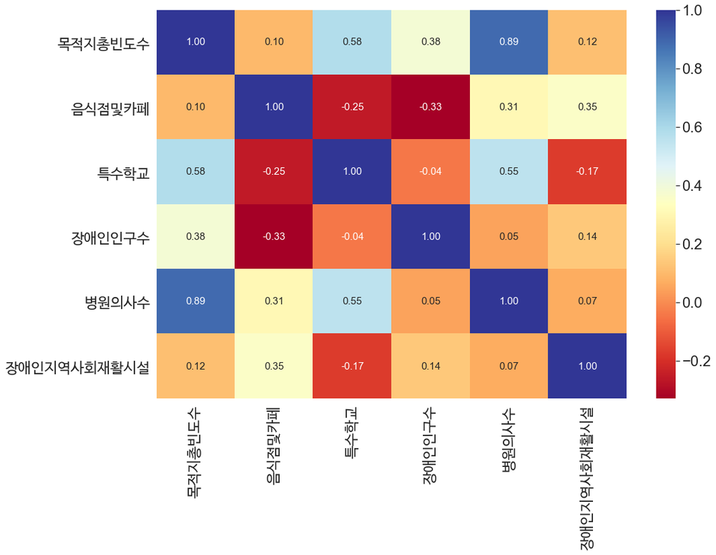

```python
fig = plt.figure(figsize = (16, 12))
ax = fig.gca()

# https://seaborn.pydata.org/generated/seaborn.heatmap.html
sns.set(font_scale = 2)  # heatmap 안의 font-size 설정
heatmap = sns.heatmap(corr.values, annot = True, fmt='.2f', annot_kws={'size':15},
                      yticklabels = cols, xticklabels = cols, ax=ax, cmap = "RdYlBu")
plt.tight_layout()
plt.show()
```

#### 4-2) k-means 클러스터링

```python
df_c=  pd.read_excel('./data/클러스터링데이터/clustering_dataset.xlsx')
df_c
```

|  | 자치구 | 장애인_거주현황 | 콜택시_평균대기시간 | 목적지출발지 |
| --- | --- | --- | --- | --- |
| 0 | 중랑구 | 20394 | 41.6 | 86700 |
| 1 | 중구 | 5700 | 51.0 | 33060 |
| 2 | 종로구 | 6015 | 51.5 | 66114 |
| 3 | 은평구 | 21773 | 49.5 | 112984 |
| 4 | 용산구 | 7960 | 48.5 | 34300 |
| 5 | 영등포구 | 14539 | 47.2 | 72960 |
| 6 | 양천구 | 17558 | 44.7 | 65180 |
| 7 | 송파구 | 20286 | 49.6 | 90445 |
| 8 | 성북구 | 17490 | 51.7 | 68349 |
| 9 | 성동구 | 11412 | 50.9 | 49690 |
| 10 | 서초구 | 10542 | 50.5 | 54806 |
| 11 | 서대문구 | 12551 | 48.8 | 108874 |
| 12 | 마포구 | 12951 | 52.3 | 95423 |
| 13 | 동작구 | 14607 | 50.4 | 56979 |
| 14 | 동대문구 | 15701 | 46.4 | 74693 |
| 15 | 도봉구 | 15436 | 45.0 | 72375 |
| 16 | 노원구 | 27312 | 42.5 | 205800 |
| 17 | 금천구 | 11390 | 53.8 | 30266 |
| 18 | 구로구 | 18280 | 50.6 | 64400 |
| 19 | 광진구 | 12353 | 42.4 | 51729 |
| 20 | 관악구 | 20265 | 50.8 | 73959 |
| 21 | 강서구 | 28727 | 48.1 | 134845 |
| 22 | 강북구 | 17441 | 49.5 | 73835 |
| 23 | 강동구 | 18307 | 42.7 | 104441 |
| 24 | 강남구 | 15200 | 47.0 | 89376 |

- EDA

```python
print(df_c.describe())
print("--------------------------------------------------")
print(df_c.info())
print("--------------------------------------------------")
print(df_c.isnull().sum())
```

```
          장애인_거주현황  콜택시_평균대기시간         목적지출발지
count     25.00000   25.000000      25.000000
mean   15767.60000   48.280000   78863.320000
std     5690.50935    3.432929   36770.682663
min     5700.00000   41.600000   30266.000000
25%    12353.00000   46.400000   56979.000000
50%    15436.00000   49.500000   72960.000000
75%    18307.00000   50.800000   90445.000000
max    28727.00000   53.800000  205800.000000
--------------------------------------------------
<class 'pandas.core.frame.DataFrame'>
RangeIndex: 25 entries, 0 to 24
Data columns (total 4 columns):
 #   Column      Non-Null Count  Dtype
---  ------      --------------  -----
 0   자치구         25 non-null     object
 1   장애인_거주현황    25 non-null     int64
 2   콜택시_평균대기시간  25 non-null     float64
 3   목적지출발지      25 non-null     int64
dtypes: float64(1), int64(2), object(1)
memory usage: 928.0+ bytes
None
--------------------------------------------------
자치구           0
장애인_거주현황      0
콜택시_평균대기시간    0
목적지출발지        0
dtype: int64
```

- PCA

```python
df_c.set_index('자치구', inplace=True)
```

```python
from sklearn.decomposition import PCA
pca = PCA(n_components=2) # 주성분을 몇개로 할지 결정
printcipalComponents = pca.fit_transform(df_c)
principalDf = pd.DataFrame(data=printcipalComponents, columns =  ['principal component1', 'principal component2'])
# 주성분으로 이루어진 데이터 프레임 구성
```

```python
from sklearn.cluster import KMeans
WCSS=[]
### 참고 https://analyticsindiamag.com/beginners-guide-to-k-means-clustering/
```

```python
for i in range (1,11):
    kmeans = KMeans(n_clusters=i, init='k-means++', random_state=0)
    kmeans.fit(df_c)
    interia=kmeans.inertia_
    #### inertia_ is the formula used to segregate the data points into clusters
    #### inertia = 관성
    #### Cluster 간의 거리의 합을 나타내는 inertia가 급격히 떨어지는 구간이 생기는데
    #### 이 지점의 K 값을 군집의 개수로 사용 inertia_속성으로 확인할 수 있다
    print('k:', i, 'inertia:', interia)
    WCSS.append(kmeans.inertia_)
```

```
k: 1 inertia: 33227160286.280003
k: 2 inertia: 14716528397.665218
k: 3 inertia: 5848013131.029375
k: 4 inertia: 3010320629.1648626
k: 5 inertia: 1797264538.655879
k: 6 inertia: 1071139822.0655556
k: 7 inertia: 498082518.33638895
k: 8 inertia: 363758909.1163333
k: 9 inertia: 260003849.59550002
k: 10 inertia: 203345301.038
```

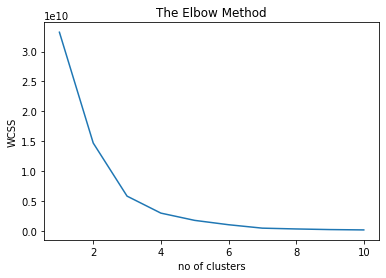

```python
plt.plot(range(1,11), WCSS)

plt.title('The Elbow Method')
plt.xlabel('no of clusters')
plt.ylabel('WCSS')
plt.show()
```

```python
### 클러스터링 전, 스케일링
from sklearn.preprocessing import StandardScaler
scaler = StandardScaler()  # 평균 0, 표준편차 1
scale_columns = ['장애인_거주현황','콜택시_평균대기시간']
df_c[scale_columns] = scaler.fit_transform(df_c[scale_columns])
df_c
```

| 자치구 | 장애인_거주현황 | 콜택시_평균대기시간 | 목적지출발지 |
| --- | --- | --- | --- |
| 중랑구 | 0.829768 | -1.985985 | 86700 |
| 중구 | -1.805673 | 0.808665 | 33060 |
| 종로구 | -1.749177 | 0.957316 | 66114 |
| 은평구 | 1.077098 | 0.362710 | 112984 |
| 용산구 | -1.400331 | 0.065407 | 34300 |
| 영등포구 | -0.220355 | -0.321087 | 72960 |
| 양천구 | 0.321117 | -1.064345 | 65180 |
| 송파구 | 0.810397 | 0.392440 | 90445 |
| 성북구 | 0.308921 | 1.016777 | 68349 |
| 성동구 | -0.781198 | 0.778934 | 49690 |
| 서초구 | -0.937237 | 0.660013 | 54806 |
| 서대문구 | -0.576913 | 0.154598 | 108874 |
| 마포구 | -0.505171 | 1.195159 | 95423 |
| 동작구 | -0.208159 | 0.630283 | 56979 |
| 동대문구 | -0.011945 | -0.558930 | 74693 |
| 도봉구 | -0.059474 | -0.975155 | 72375 |
| 노원구 | 2.070545 | -1.718413 | 205800 |
| 금천구 | -0.785144 | 1.641114 | 30266 |
| 구로구 | 0.450611 | 0.689743 | 64400 |
| 광진구 | -0.612425 | -1.748143 | 51729 |
| 관악구 | 0.806631 | 0.749204 | 73959 |
| 강서구 | 2.324332 | -0.053515 | 134845 |
| 강북구 | 0.300132 | 0.362710 | 73835 |
| 강동구 | 0.455454 | -1.658952 | 104441 |
| 강남구 | -0.101802 | -0.380548 | 89376 |

```python
### clustering
from sklearn.cluster import KMeans
kmeans = KMeans(n_clusters=4,random_state=2020).fit(df_c[['장애인_거주현황','콜택시_평균대기시간','목적지출발지']])
labels=kmeans.labels_
centers=kmeans.cluster_centers_
```

```python
df_c['clustering']=labels
df_c
```

| 자치구 | 장애인_거주현황 | 콜택시_평균대기시간 | 목적지출발지 | clustering |
| --- | --- | --- | --- | --- |
| 중랑구 | 0.829768 | -1.985985 | 86700 | 0 |
| 중구 | -1.805673 | 0.808665 | 33060 | 3 |
| 종로구 | -1.749177 | 0.957316 | 66114 | 0 |
| 은평구 | 1.077098 | 0.362710 | 112984 | 1 |
| 용산구 | -1.400331 | 0.065407 | 34300 | 3 |
| 영등포구 | -0.220355 | -0.321087 | 72960 | 0 |
| 양천구 | 0.321117 | -1.064345 | 65180 | 0 |
| 송파구 | 0.810397 | 0.392440 | 90445 | 0 |
| 성북구 | 0.308921 | 1.016777 | 68349 | 0 |
| 성동구 | -0.781198 | 0.778934 | 49690 | 3 |
| 서초구 | -0.937237 | 0.660013 | 54806 | 3 |
| 서대문구 | -0.576913 | 0.154598 | 108874 | 1 |
| 마포구 | -0.505171 | 1.195159 | 95423 | 1 |
| 동작구 | -0.208159 | 0.630283 | 56979 | 3 |
| 동대문구 | -0.011945 | -0.558930 | 74693 | 0 |
| 도봉구 | -0.059474 | -0.975155 | 72375 | 0 |
| 노원구 | 2.070545 | -1.718413 | 205800 | 2 |
| 금천구 | -0.785144 | 1.641114 | 30266 | 3 |
| 구로구 | 0.450611 | 0.689743 | 64400 | 0 |
| 광진구 | -0.612425 | -1.748143 | 51729 | 3 |
| 관악구 | 0.806631 | 0.749204 | 73959 | 0 |
| 강서구 | 2.324332 | -0.053515 | 134845 | 1 |
| 강북구 | 0.300132 | 0.362710 | 73835 | 0 |
| 강동구 | 0.455454 | -1.658952 | 104441 | 1 |
| 강남구 | -0.101802 | -0.380548 | 89376 | 0 |

```python
df_c.to_excel('./data/클러스터링데이터/clustering_dataset_label.xlsx')
```

클러스터링 시각화 부분은 R로 하였습니다.

#### 4-3) 회귀분석

- 데이터 스케일링

```python
df = df_.copy()
```

```python
# resampling 10000회
df=df.sample(10000, replace=True)
```

```python
# 표준화
from sklearn.preprocessing import StandardScaler
scaler = StandardScaler()
scale_columns =['목적지총빈도수', '음식점및카페', '특수학교', '장애인인구수', '병원의사수', '장애인지역사회재활시설']

df[scale_columns] = scaler.fit_transform(df[scale_columns])
df
```

|  | 관악구행정동 | 목적지총빈도수 | 쇼핑 | 장애인재활시설 | 장애인거주시설 | 음식점 | 병원 | 특수학교 | 커피전문점 | 특수학급및학교 | 장애인복지시설 | 다중복합시설 | 음식점및카페 | 장애인인구수 | 병원의사수 | 장애인지역사회재활시설 | 장애인거주시설.1 | 장애인의료재활시설 | 장애인직업재활시설 |
| --- | --- | --- | --- | --- | --- | --- | --- | --- | --- | --- | --- | --- | --- | --- | --- | --- | --- | --- | --- |
| 19 | 신림동 | -0.640841 | 1.0 | 0.0 | 0.0 | 141.0 | 45.0 | -0.327562 | 45.0 | 0.0 | 0.0 | 1.0 | 1.468976 | -1.135207 | 0.309765 | -0.519775 | 0.0 | 0.0 | 0.0 |
| 13 | 대학동 | -0.379577 | 0.0 | 0.0 | 0.0 | 136.0 | 14.0 | -0.327562 | 68.0 | 5.0 | 0.0 | 0.0 | 1.799964 | -0.648273 | -0.493940 | -0.519775 | 0.0 | 0.0 | 0.0 |
| 5 | 보라매동 | 3.765481 | 1.0 | 1.0 | 1.0 | 81.0 | 16.0 | 3.052854 | 33.0 | 4.0 | 2.0 | 1.0 | 0.145024 | 0.454167 | 3.962971 | -0.519775 | 1.0 | 1.0 | 0.0 |
| 20 | 낙성대동 | -0.103594 | 0.0 | 1.0 | 0.0 | 126.0 | 22.0 | -0.327562 | 66.0 | 0.0 | 1.0 | 0.0 | 1.579305 | -1.359524 | -0.128620 | 0.847335 | 0.0 | 0.0 | 0.0 |
| 10 | 서림동 | -0.308435 | 1.0 | 0.0 | 0.0 | 64.0 | 12.0 | -0.327562 | 25.0 | 3.0 | 0.0 | 0.0 | -0.314681 | -0.265292 | -0.542650 | -0.519775 | 0.0 | 0.0 | 0.0 |
| ... | ... | ... | ... | ... | ... | ... | ... | ... | ... | ... | ... | ... | ... | ... | ... | ... | ... | ... | ... |
| 17 | 중앙동 | -0.451946 | 1.0 | 0.0 | 0.0 | 80.0 | 37.0 | -0.327562 | 20.0 | 2.0 | 0.0 | 0.0 | -0.112411 | -1.066817 | 0.017509 | -0.519775 | 0.0 | 0.0 | 0.0 |
| 18 | 남현동 | -0.761456 | 1.0 | 0.0 | 0.0 | 64.0 | 20.0 | -0.327562 | 25.0 | 3.0 | 0.0 | 1.0 | -0.314681 | -1.118793 | -0.445231 | -0.519775 | 0.0 | 0.0 | 0.0 |
| 16 | 청림동 | -0.714437 | 0.0 | 0.0 | 0.0 | 13.0 | 5.0 | -0.327562 | 13.0 | 1.0 | 0.0 | 0.0 | -1.473139 | -0.834293 | -0.688778 | -0.519775 | 0.0 | 0.0 | 0.0 |
| 11 | 신원동 | -0.788441 | 2.0 | 0.0 | 0.0 | 63.0 | 14.0 | -0.327562 | 11.0 | 4.0 | 0.0 | 0.0 | -0.590504 | -0.265292 | -0.567004 | -0.519775 | 0.0 | 0.0 | 0.0 |
| 13 | 대학동 | -0.379577 | 0.0 | 0.0 | 0.0 | 136.0 | 14.0 | -0.327562 | 68.0 | 5.0 | 0.0 | 0.0 | 1.799964 | -0.648273 | -0.493940 | -0.519775 | 0.0 | 0.0 | 0.0 |

10000 rows × 19 columns

- train/test셋으로 나누기

```python
dfx = df[scale_columns].drop('목적지총빈도수', axis=1)
dfx
```

|  | 음식점및카페 | 특수학교 | 장애인인구수 | 병원의사수 | 장애인지역사회재활시설 |
| --- | --- | --- | --- | --- | --- |
| 19 | 1.468976 | -0.327562 | -1.135207 | 0.309765 | -0.519775 |
| 13 | 1.799964 | -0.327562 | -0.648273 | -0.493940 | -0.519775 |
| 5 | 0.145024 | 3.052854 | 0.454167 | 3.962971 | -0.519775 |
| 20 | 1.579305 | -0.327562 | -1.359524 | -0.128620 | 0.847335 |
| 10 | -0.314681 | -0.327562 | -0.265292 | -0.542650 | -0.519775 |
| ... | ... | ... | ... | ... | ... |
| 17 | -0.112411 | -0.327562 | -1.066817 | 0.017509 | -0.519775 |
| 18 | -0.314681 | -0.327562 | -1.118793 | -0.445231 | -0.519775 |
| 16 | -1.473139 | -0.327562 | -0.834293 | -0.688778 | -0.519775 |
| 11 | -0.590504 | -0.327562 | -0.265292 | -0.567004 | -0.519775 |
| 13 | 1.799964 | -0.327562 | -0.648273 | -0.493940 | -0.519775 |

10000 rows × 5 columns

```python
from sklearn.model_selection import train_test_split
X = dfx
y = df['목적지총빈도수']
X_train, X_test, y_train, y_test = train_test_split(X, y, test_size=0.2, random_state=1)
```

- 다중공선성

```python
from statsmodels.stats.outliers_influence import variance_inflation_factor

vif = pd.DataFrame()
vif['features'] = X_train.columns
vif["VIF Factor"] = [variance_inflation_factor(X_train.values, i) for i in range(X_train.shape[1])]
vif.round(1)
### 소수점 첫째자리까지 표시합니다. 즉, 소수점 둘째짜리에서 반올림 합니다.
```

|  | features | VIF Factor |
| --- | --- | --- |
| 0 | 음식점및카페 | 2.3 |
| 1 | 특수학교 | 2.4 |
| 2 | 장애인인구수 | 1.4 |
| 3 | 병원의사수 | 2.5 |
| 4 | 장애인지역사회재활시설 | 1.3 |

- 회귀모델링

```python
from sklearn import linear_model

# fit regression model in training set
lr = linear_model.LinearRegression()
model = lr.fit(X_train, y_train)

# predict in test set
pred_test = lr.predict(X_test)
```

- 모델 해석하기

```python
coefs = pd.DataFrame(zip(dfx.columns, lr.coef_), columns = ['feature', 'coefficients'])
coefs_new = coefs.reindex(coefs.coefficients.abs().sort_values(ascending=False).index)
coefs_new
```

|  | feature | coefficients |
| --- | --- | --- |
| 3 | 병원의사수 | 0.769400 |
| 2 | 장애인인구수 | 0.345662 |
| 1 | 특수학교 | 0.176611 |
| 4 | 장애인지역사회재활시설 | 0.042290 |
| 0 | 음식점및카페 | 0.008054 |

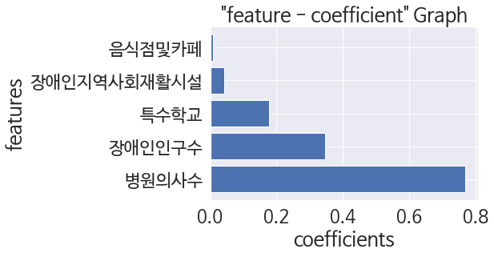

```python
plt.barh(coefs_new['feature'], coefs_new['coefficients'])
plt.title('"feature - coefficient" Graph')
plt.xlabel('coefficients')
plt.ylabel('features')
plt.show()
```

- 유의성 검정

```python
import statsmodels.api as sm

X_train2 = sm.add_constant(X_train)
### 회귀분석모형 수식을 간단하게 만들기 위해 다음과 같이 상수항을 독립변수 데이터에 추가하는 것을 상수항 결합(bias augmentation)작업이라고 합니다.
### ordinary least square 의 약자로, 거리의 최소값을 기준으로 구하는 함수입니다.

model2 = sm.OLS(y_train, X_train2).fit()
model2.summary()
```

OLS Regression Results

| Dep. Variable: | 목적지총빈도수 | R-squared: | 0.930 |
| --- | --- | --- | --- |
| Model: | OLS | Adj. R-squared: | 0.930 |
| Method: | Least Squares | F-statistic: | 2.140e+04 |
| Date: | Sun, 12 Dec 2021 | Prob (F-statistic): | 0.00 |
| Time: | 19:12:21 | Log-Likelihood: | -773.34 |
| No. Observations: | 8000 | AIC: | 1559. |
| Df Residuals: | 7994 | BIC: | 1601. |
| Df Model: | 5 |  |  |
| Covariance Type: | nonrobust |  |  |

|  | coef | std err | t | P>\|t\| | [0.025 | 0.975] |
| --- | --- | --- | --- | --- | --- | --- |
| const | 0.0012 | 0.003 | 0.397 | 0.692 | -0.005 | 0.007 |
| 음식점및카페 | 0.0081 | 0.005 | 1.771 | 0.077 | -0.001 | 0.017 |
| 특수학교 | 0.1766 | 0.005 | 38.771 | 0.000 | 0.168 | 0.186 |
| 장애인인구수 | 0.3457 | 0.004 | 96.915 | 0.000 | 0.339 | 0.353 |
| 병원의사수 | 0.7694 | 0.005 | 165.270 | 0.000 | 0.760 | 0.779 |
| 장애인지역사회재활시설 | 0.0423 | 0.003 | 12.631 | 0.000 | 0.036 | 0.049 |

| Omnibus: | 733.610 | Durbin-Watson: | 2.016 |
| --- | --- | --- | --- |
| Prob(Omnibus): | 0.000 | Jarque-Bera (JB): | 289.949 |
| Skew: | -0.245 | Prob(JB): | 1.09e-63 |
| Kurtosis: | 2.207 | Cond. No. | 3.09 |

Notes:  
[1] Standard Errors assume that the covariance matrix of the errors is correctly specified.

- 예측 결과

```python
### 예측 결과 시각화 (test set)
df = pd.DataFrame({'actual': y_test, 'prediction': pred_test})
df = df.sort_values(by='actual').reset_index(drop=True)
df.head()
```

|  | actual | prediction |
| --- | --- | --- |
| 0 | -0.836278 | -0.382832 |
| 1 | -0.836278 | -0.382832 |
| 2 | -0.836278 | -0.382832 |
| 3 | -0.836278 | -0.382832 |
| 4 | -0.836278 | -0.382832 |

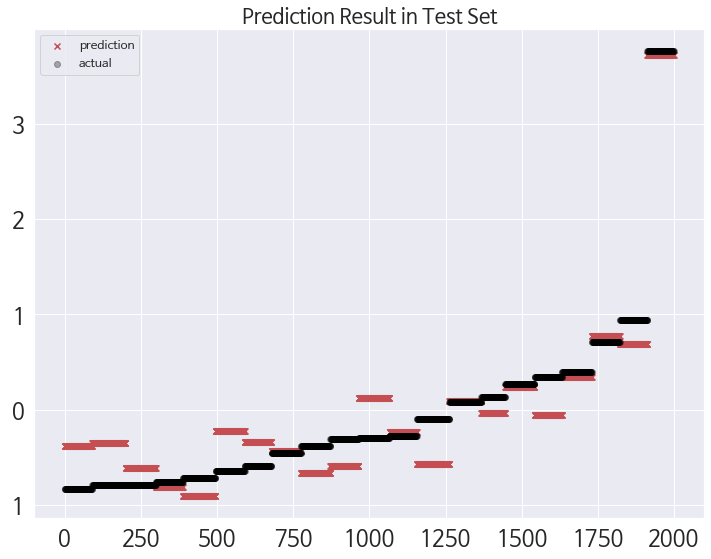

```python
plt.figure(figsize=(12, 9))
plt.scatter(df.index, df['prediction'], marker='x', color='r')
plt.scatter(df.index, df['actual'], alpha=0.3, marker='o', color='black')
plt.title("Prediction Result in Test Set", fontsize=20)
plt.legend(['prediction', 'actual'], fontsize=12)
plt.show()
```

- 모델 성능 평가

```python
### R square
print(model.score(X_train, y_train))  # training set
print(model.score(X_test, y_test))  # test set
```

```
0.930482561425559
0.9171376883392989
```

```python
# RMSE
from sklearn.metrics import mean_squared_error
from math import sqrt

# training set
pred_train = lr.predict(X_train)
print(sqrt(mean_squared_error(y_train, pred_train)))

# test set
print(sqrt(mean_squared_error(y_test, pred_test)))
```

```
0.2665291923005421
0.2746666422992337
```

### 5. 결과

관악구에서 선정한 버스 정류장을 지도 위에 시각화 하기

```python
pip install folium
```

```python
import folium
```

```python
df = pd.read_excel('./data/버스정류장데이터/관악구버스정류장.xlsx', sheet_name='행정동별탑승건')
df1 = pd.read_excel('./data/버스정류장데이터/관악구버스정류장.xlsx', sheet_name='장애인무료셔틀버스')
s_df = pd.read_excel('./data/버스정류장데이터/관악구버스정류장.xlsx', sheet_name='서원동버스정류장')
b_df = pd.read_excel('./data/버스정류장데이터/관악구버스정류장.xlsx', sheet_name='보라매동버스정류장')
c_df = pd.read_excel('./data/버스정류장데이터/관악구버스정류장.xlsx', sheet_name='청룡동버스정류장')
h_df = pd.read_excel('./data/버스정류장데이터/관악구버스정류장.xlsx', sheet_name='행운동버스정류장')
```

```python
# geo_data = 'dongjak_road.geojson'
# 행정동이 들어가있는 파일 업로드
import json
# open("tree.dot",encoding='UTF-8')
with open('./data/버스정류장데이터/seoul-dong.geojson',encoding='UTF-8') as f:
    geo_data = json.load(f)
```

```python
# df['행정동']과 df1['행정동'] join 시켜서 df의 순위 추가하기
df_INNER_JOIN = pd.merge(df, df1, left_on='행정동', right_on='행정동', how='inner')
df_INNER_JOIN
```

|  | 행정동 | 2021탑승건 | 순위 | Unnamed: 3 | 행정동.1 | 2020탑승건 | 순위.1 | Unnamed: 7 | 행정동.2 | 탑승건합 | 순위.2 | 버스정류장 | 위도 | 경도 | 위치 |
| --- | --- | --- | --- | --- | --- | --- | --- | --- | --- | --- | --- | --- | --- | --- | --- |
| 0 | 보라매동 | 6075.0 | 1.0 | NaN | 보라매동 | 6563.0 | 1.0 | NaN | 보라매동 | 12638.0 | 1.0 | 관악노인종합복지관 | 37.492995 | 126.926587 | 37.492995279135904, 126.92658652731673 |
| 1 | 은천동 | 2565.0 | 2.0 | NaN | 은천동 | 2421.0 | 2.0 | NaN | 은천동 | 4986.0 | 1.0 | 봉일시장 | 37.486228 | 126.938307 | 37.48622838676283, 126.93830663558224 |
| 2 | 은천동 | 2565.0 | 2.0 | NaN | 은천동 | 2421.0 | 2.0 | NaN | 은천동 | 4986.0 | 1.0 | 현대시장사거리 | 37.486876 | 126.946940 | 37.48687565897052, 126.9469403752853 |
| 3 | 성현동 | 2373.0 | 2.0 | NaN | 청룡동 | 2270.0 | 2.0 | NaN | 청룡동 | 4594.0 | 1.0 | 동부센트레빌아파트 | 37.486508 | 126.950796 | 37.48650792830431, 126.95079551839204 |
| 4 | 청룡동 | 2324.0 | 2.0 | NaN | 난향동 | 2181.0 | 2.0 | NaN | 성현동 | 4034.0 | 1.0 | 서울대입구역 | 37.481231 | 126.952717 | 37.48123128474503, 126.95271736441775 |
| 5 | 청룡동 | 2324.0 | 2.0 | NaN | 난향동 | 2181.0 | 2.0 | NaN | 성현동 | 4034.0 | 1.0 | 관악구청 | 37.478518 | 126.952236 | 37.478517712643935, 126.95223602360394 |
| 6 | 난곡동 | 1843.0 | 3.0 | NaN | 난곡동 | 1910.0 | 3.0 | NaN | 행운동 | 3806.0 | 2.0 | 난곡기점(보성운수 차고지) | 37.464838 | 126.919279 | 37.464837830609596, 126.91927872593693 |
| 7 | 난곡동 | 1843.0 | 3.0 | NaN | 난곡동 | 1910.0 | 3.0 | NaN | 행운동 | 3806.0 | 2.0 | 난곡보건분소 | 37.469478 | 126.920088 | 37.4694782119135, 126.92008770120184 |
| 8 | 난곡동 | 1843.0 | 3.0 | NaN | 난곡동 | 1910.0 | 3.0 | NaN | 행운동 | 3806.0 | 2.0 | GS칼텍스주유소(난곡점) | 37.473283 | 126.918768 | 37.47328345479168, 126.91876784510681 |
| 9 | 미성동 | 1362.0 | 3.0 | NaN | 서림동 | 1430.0 | 3.0 | NaN | 서림동 | 2877.0 | 2.0 | 미동성국민은행맞은편 | 37.477107 | 126.915722 | 37.47710691446221, 126.91572230381193 |
| 10 | 중앙동 | 1298.0 | 3.0 | NaN | 중앙동 | 1336.0 | 3.0 | NaN | 중앙동 | 2634.0 | 2.0 | 관악신협 | 37.483051 | 126.946640 | 37.48305072989838, 126.94663989408195 |
| 11 | 중앙동 | 1298.0 | 3.0 | NaN | 중앙동 | 1336.0 | 3.0 | NaN | 중앙동 | 2634.0 | 2.0 | 동진부페 | 37.484216 | 126.954888 | 37.48421586707278, 126.95488838345625 |
| 12 | 신사동 | 600.0 | 4.0 | NaN | 조원동 | 630.0 | 4.0 | NaN | 신사동 | 1417.0 | 3.0 | 난곡입구 | 37.482018 | 126.915617 | 37.48201836548489, 126.91561652023097 |
| 13 | 신사동 | 600.0 | 4.0 | NaN | 조원동 | 630.0 | 4.0 | NaN | 신사동 | 1417.0 | 3.0 | 난곡사거리(구 건강보험공단 앞) | 37.481839 | 126.914477 | 37.481838872325135, 126.91447698211154 |
| 14 | 신사동 | 600.0 | 4.0 | NaN | 조원동 | 630.0 | 4.0 | NaN | 신사동 | 1417.0 | 3.0 | 신대방역(신사동 신사지구대) | 37.487341 | 126.913986 | 37.4873409828629, 126.91398582194249 |

```python
s_df
```

|  | 버스정류장 | 정류소번호 | 경도 | 위도 | 200m안 병원 개수 | 200m 안 장애인지역사회재활시설 개수 | 200m안 음식점카페 개수 | 장애인인구수 | 특수학교 | 회귀식점수(소수점2자리까지) | 회귀식점수반올림 | 회귀계수둘째자리올림 | 입지선정 | 비고 |
| --- | --- | --- | --- | --- | --- | --- | --- | --- | --- | --- | --- | --- | --- | --- |
| 0 | 서원치안센터(21913) | 21913.0 | 126.9291 | 37.48203 | 3.0 | 1.0 | 128.0 | 804.0 | 0.0 | 276.95 | 277.0 | 286.31 | 0.0 | NaN |
| 1 | 삼모타워앞(21582) | 21582.0 | 126.9284 | 37.48235 | 3.0 | 1.0 | 126.0 | 804.0 | 0.0 | 276.93 | 277.0 | 286.27 | 1.0 | NaN |
| 2 | 신림역4번출구(21916) | 21916.0 | 126.9290 | 37.48406 | 3.0 | 0.0 | 110.0 | 804.0 | 0.0 | 276.74 | 277.0 | 285.91 | 1.0 | NaN |
| 3 | 신림사거리(21153) | 21153.0 | 126.9297 | 37.48277 | 3.0 | 1.0 | 107.0 | 804.0 | 0.0 | 276.74 | 277.0 | 285.89 | 1.0 | NaN |
| 4 | 서원동승리교앞(21369) | 21369.0 | 126.9298 | 37.48160 | 3.0 | 1.0 | 94.0 | 804.0 | 0.0 | 276.61 | 277.0 | 285.63 | 0.0 | NaN |
| 5 | 신림역2번출구(21377) | 21377.0 | 126.9298 | 37.48332 | 3.0 | 1.0 | 91.0 | 804.0 | 0.0 | 276.58 | 277.0 | 285.57 | 1.0 | NaN |
| 6 | 신림사거리(21148) | 21148.0 | 126.9299 | 37.48192 | 3.0 | 1.0 | 88.0 | 804.0 | 0.0 | 276.55 | 277.0 | 285.51 | 0.0 | NaN |
| 7 | 신림사거리.신림역(21350) | 21350.0 | 126.9283 | 37.48415 | 2.0 | 0.0 | 122.0 | 804.0 | 0.0 | 276.10 | 276.0 | 285.38 | 0.0 | NaN |
| 8 | 신림사거리.신림역(21117) | 21117.0 | 126.9274 | 37.48386 | 2.0 | 0.0 | 119.0 | 804.0 | 0.0 | 276.07 | 276.0 | 285.32 | 0.0 | NaN |
| 9 | 신림사거리.신원시장(21604) | 21604.0 | 126.9274 | 37.48386 | 2.0 | 0.0 | 109.0 | 804.0 | 0.0 | 275.97 | 276.0 | 285.12 | 0.0 | NaN |
| 10 | 봉림교(21912) | 21912.0 | 126.9268 | 37.48361 | 0.0 | 0.0 | 97.0 | 804.0 | 0.0 | 274.33 | 274.0 | 283.34 | 0.0 | NaN |
| 11 | 관악우체국.양지병원(21262) | 21262.0 | 126.9331 | 37.48457 | 1.0 | 0.0 | 43.0 | 804.0 | 0.0 | 274.55 | 275.0 | 283.03 | 1.0 | NaN |
| 12 | GS편의점(21542) | 21542.0 | 126.9306 | 37.47845 | 0.0 | 0.0 | 28.0 | 804.0 | 0.0 | 273.64 | 274.0 | 281.96 | 0.0 | NaN |
| 13 | 서원동문화교앞(21154) | 21154.0 | 126.9330 | 37.47777 | 0.0 | 0.0 | 26.0 | 804.0 | 0.0 | 273.62 | 274.0 | 281.92 | 0.0 | NaN |
| 14 | 서원동문화교앞(21147) | 21147.0 | 126.9323 | 37.47859 | 0.0 | 0.0 | 25.0 | 804.0 | 0.0 | 273.61 | 274.0 | 281.90 | 0.0 | NaN |
| 15 | 신림2교(21375) | 21375.0 | 126.9367 | 37.47741 | 0.0 | 0.0 | 23.0 | 804.0 | 0.0 | 273.59 | 274.0 | 281.86 | 0.0 | NaN |
| 16 | 혜성세탁소(21532) | 21532.0 | 126.9303 | 37.47738 | 0.0 | 0.0 | 13.0 | 804.0 | 0.0 | 273.49 | 273.0 | 281.66 | 0.0 | NaN |
| 17 | 신본교.서원동성당앞(21919) | 21919.0 | 126.9345 | 37.47780 | 0.0 | 0.0 | 6.0 | 804.0 | 0.0 | 273.42 | 273.0 | 281.52 | 0.0 | NaN |
| 18 | 미성빌라(21522) | 21522.0 | 126.9303 | 37.47708 | 0.0 | 0.0 | 3.0 | 804.0 | 0.0 | 273.39 | 273.0 | 281.46 | 0.0 | NaN |
| 19 | 코사마트(21513) | 21513.0 | 126.9302 | 37.47622 | 0.0 | 0.0 | 2.0 | 804.0 | 0.0 | 273.38 | 273.0 | 281.44 | 0.0 | NaN |

```python
# 중심좌표
center = [37.666144173608785, 127.07776777439291]

m = folium.Map(location=center, zoom_start=10)

# Choropleth 레이어를 만들고, 맵 m에 추가
folium.Choropleth(
    geo_data=geo_data,
    data=df,
    columns=('행정동', '순위.2'),
    key_on='feature.properties.동',
    fill_color='BuPu',
).add_to(m)


for i in range(len(df_INNER_JOIN)):
    a = df_INNER_JOIN['위도'].loc[i]
    b = df_INNER_JOIN['경도'].loc[i]

  #df컬럼의 순위 추가하면 이 코드로 해보기
    if df_INNER_JOIN['순위.2'].loc[i] == 1:
        ra = 200
    elif df_INNER_JOIN['순위.2'].loc[i] == 2:
        ra = 250
    else:
        ra = 300
    folium.Circle(radius=ra,location=[a, b], popup='Sewoon sannga', color='#3186cc',fill=True, fill_color='#3186cc').add_to(m)


hanjungdong = [s_df, b_df, c_df]
for i in hanjungdong:
    for j in range(len(i)):
        if i.loc[j,'입지선정'] == 1:
            a =  i.loc[j,'위도']
            b = i.loc[j,'경도']
            folium.Circle(radius=200,location=[a, b], popup='Sewoon sannga', color='red',fill=True, fill_color='red').add_to(m)
m
```

Make this Notebook Trusted to load map: File -> Trust Notebook

[interactive chart not shown]